# Pricing Options Using Analytical & Numerical Methods

# Table of Contents

## 1. Introduction

This section is based on ideas found in [4].

Options are a type of financial derivative, which is a financial instrument linked to the inherent value of an underlying financial asset, most commonly a stock, commodity, or some other financial indicator. Since their invention, financial derivatives, and in turn options, have proved to be an incredibly liquid instrument themselves, widely available to be traded in a similar manner to the underlying asset.

Throughout this project, we are concerned with options. Options are a type of derivative that grant the holder the option to either buy or sell an underlying security at the pre-agreed strike price, often denoted by $K$.

An option that grants the holder the ability to buy the underlying security at price $K$ is known as a call, whilst an option that allows the holder to sell the security at the predetermined price is known as a put.

Within the world of options, there are a plethora of different varieties. This project starts by considering both numerical and analytical methods for pricing European options (which are considered the most vanilla) before attempting to port over the solutions derived to a slightly more exotic variant of option, known as a Barrier option. We compare the two methods and ultimately draw conclusions about the advantages and disadvantages of each.

## 2. Theoretical Context

This section is based on ideas found in [5] and [8].

### 2.1 Modelling Stock Prices Using Geometric Brownian Motion

We will model the underlying security using Geometric Brownian Motion ("GBM"), which is an assumption for the Black-Scholes Theorem ("BST"), which we shall explore in more detail when considering analytical methods for pricing European options.

We have that the Stochastic Differential Equation ("SDE") for GBM is

$$ dS(t) = \alpha\,S(t)\,dt + \sigma\,S(t)\,dW(t) $$

where $\alpha$ reflects a constant mean rate of return for the stock, $\sigma$ reflects a constant volatility for the stock, and $S(t)$ represents the price of the stock at time $t$.

In order to find a solution to the SDE above, we require Itô's Lemma, which we state below:

**Theorem 2.1** (Itô's Lemma). Let $X(t), t \geq 0$ be an Itô process, and let $f(t, x)$ be a function for which the partial derivatives $f_{t}(t, x)$, $f_{x}(t, x)$, and $f_{xx}(t, x)$ are defined and continuous. Then for every $T \geq 0$, we have that

$$ f(T, X(T)) = f(0, X(0)) + \int_{0}^{T}f_{t}(t, X(t))\,dt + \int_{0}^{T}f_{x}(t, X(t))\,dX(t) + \frac{1}{2}\int_{0}^{T}f_{xx}(t, X(t))\,d[X, X](t), $$

which can be rewritten more memorably in its differential form

$$ df(t, X(t)) = f_{t}(t, X(t))\,dt + f_{x}(t, X(t)\,dX(t) + \frac{1}{2}f_{xx}(t, X(t))\,dX(t)dX(t). $$

We can use Itô's Lemma to solve our SDE for GBM.

Let $f(t, x) = \log(x)$, where $\log(x)$ is the natural logarithm. Then, we have that

$$ f_{t}(t, x) = 0,\\ f_{x}(t, x) = \frac{1}{x}, \text{and}\\ f_{xx}(t, x) = -\frac{1}{x^2}. $$

Thus, by Itô's Lemma, we have that

$$ \begin{align*} d(\log(S(t)) &= f_{t}(t, S(t))\,dt + f_{x}(t, S(t))\,dS(t) + \frac{1}{2}f_{xx}(t, S(t))\,dS(t)dS(t)\\ &= \frac{1}{S(t)}\,dS(t) - \frac{1}{2S^2(t)}\,dS(t)dS(t)\\ &= \frac{1}{S(t)}(\alpha\,S(t)\,dt + \sigma\,S(t)\,dW(t)) - \frac{1}{2S^2(t)}[(\alpha\,S(t)\,dt + \sigma\,S(t)\,dW(t))(\alpha\,S(t)\,dt + \sigma\,S(t)\,dW(t))]\\ &= \alpha\,dt + \sigma\,dW(t) - \frac{1}{2S^2(t)}\left(\alpha^2\,S^2(t)\,dtdt + 2\sigma\alpha\,S^2(t)\,dtdW(t) + \sigma^2\,S^2(t)\,dW(t)dW(t)\right)\\ &=\alpha\,dt + \sigma\,dW(t) - \frac{1}{2S^2(t)}\left(\sigma^2\,S^2(t)\,dt\right)\\ &= \sigma\,dW(t) + \left(\alpha - \frac{1}{2}\sigma^2\right)\,dt, \end{align*}$$

where $W(t)$ represents standard Brownian Motion.

Taking the integral of both sides, we get the following

$$ \begin{align*} \log(S(t)) &= \log(S(0)) + \int_{0}^{t}\sigma\,dW(s) + \int_{0}^{t}\alpha - \frac{1}{2}\sigma^2\,ds\\ &= \log(S(0)) + \sigma\,W(t) + \left(\alpha - \frac{1}{2}\sigma^2\right)t. \end{align*}$$

Taking exponents of both sides gives us the formula for $S(t)$:

$$\begin{align*} S(t) &= \exp\left\{\log(S(t)\right\}\\ &= \exp\left\{\log(S(0)) + \sigma\,W(t) + \left(\alpha - \frac{1}{2}\sigma^2\right)t\right\}\\ &= S(0)\exp\left\{\sigma\,W(t) + \left(\alpha - \frac{1}{2}\sigma^2\right)t\right\}. \end{align*}$$

We note immediately that under the GBM model, the stock price $S(t)$ can only take positive values, given an initial positive price. That is to say that $S(t) \ge 0$ for all $t \ge 0$ given that $S(0) \ge 0$. This is one of the reasons why the model is considered a satisfactory model of stock prices.

In order to test our analytical and numerical pricing methods, we will need to be able to simulate stock prices. To do this, we need to discretise the continuous GBM formula for $S(t)$ provided above.

We will consider $S(t)$ over a very small time, say $\Delta(t)$. We note that given $S(t)$, we can iteratively calculate $S(t + \Delta(t))$ using our derived formula for $S(t)$. We have that

$$\begin{align*} S(t+\Delta(t)) &\approx S(0)\exp\left\{\sigma\,W(t+\Delta(t)) + \left(\alpha - \frac{1}{2}\sigma^2\right)\left(t + \Delta(t)\right)\right\}. \end{align*}$$

Thus, we have that

$$\begin{align*} \frac{S(t+\Delta(t))}{S(t)} &= \frac{S(0)\exp\left\{\sigma\,W(t+\Delta(t)) + \left(\alpha - \frac{1}{2}\sigma^2\right)(t + \Delta(t))\right\}}{S(0)\exp\left\{\sigma\,W(t) + \left(\alpha - \frac{1}{2}\sigma^2\right)(t)\right\}}\\ &= \exp\left\{\sigma\,W(t + \Delta(t)) + \left(\alpha - \frac{1}{2}\sigma^2\right)(t + \Delta(t)) - \sigma\,W(t) - \left(\alpha - \frac{1}{2}\sigma^2\right)t\right\}\\ &= \exp\left\{\sigma(W(t + \Delta(t)) - W(t)) + \left(\alpha - \frac{1}{2}\sigma^2\right)(\Delta(t))\right\}. \end{align*}$$

We note that, by the definition of Brownian Motion, that $W(t + \Delta(t)) - W(t)) \sim \mathcal{N}\left(0, \Delta(t)\right)$ and thus we have that $W(t + \Delta(t)) - W(t)) = \sqrt{\Delta(t)}Z$, where $Z \sim \mathcal{N}\left(0, 1\right)$.

Taking this together, we have that

$$\begin{align*} \frac{S(t+\Delta(t))}{S(t)} &= \exp\left\{\sigma\sqrt{\Delta(t)}Z + \left(\alpha - \frac{1}{2}\sigma^2\right)(\Delta(t))\right\}. \end{align*}$$

Rearranging for $S(t + \Delta(t))$ gives the following iterative approximation

$$ S(t + \Delta(t)) = S(t)\exp\left\{\sigma\sqrt{\Delta(t)}Z + \left(\alpha - \frac{1}{2}\sigma^2\right)(\Delta(t))\right\}, $$

which we can use to simulate GBM.

Below we show such a simulation:

```python
import numpy as np
import matplotlib.pyplot as plt
```

```python
'''
simulate_gbm below takes parameters S_0, sigma, alpha, dt, and T, before returning an array of stock prices in jumps of dt
between 0 and T that are modelled on GBM.

S_0 represents the initial stock price
sigma represents the volatility of the stock
alpha represents the mean rate of return of the stock
dt reflects the size of the jumps we use in this discretisation of the continuous-time GBM model
T represents the final time in the period we model the stock for
'''

def simulate_gbm(S_0, sigma, alpha, dt, T):
    N = int(T / dt) #We calculate how many data points we will have
    stock_prices = np.zeros(N)

    stock_prices[0] = S_0

    for i in range(1, N):
        stock_prices[i] = stock_prices[i-1]*np.exp(sigma*np.sqrt(dt)*np.random.randn() + (alpha - 0.5*sigma**2)*dt)

    return stock_prices
```

Below we use the function to generate prices for a stock with initial price $S(0) = 30$, volatility $\sigma = 0.05$, and mean rate of return $\alpha = 0.02$, simulated between $t = 0$ and $t = 10$ in time steps of $dt = 0.05$.

```python
S_0 = 30
sigma = 0.05
alpha = 0.02
dt = 0.05
T = 10
stock_price = simulate_gbm(S_0, sigma, alpha, dt, T)
print(stock_price)
```

```
[30.         30.29380359 30.32247443 30.63829714 30.7035605  31.02296098
 31.05864648 31.44617499 31.39435878 31.07429363 30.50335105 29.88697011
 29.74166172 29.79446349 29.86953658 30.22715945 30.50717357 30.71490142
 30.66074136 30.8598549  30.98489902 31.64927764 31.49788685 31.52639788
 31.94971605 31.83897673 31.97159345 31.67734337 31.95775427 32.50544765
 33.43435659 33.4606399  32.9087447  32.38467845 32.12554168 31.2732269
 31.06537601 31.36087607 31.72552388 31.42275426 30.9252289  30.7417312
 31.1594656  32.11026425 32.18208077 32.17215854 32.02388315 31.69220687
 31.45120697 31.46004145 31.61943608 31.21928162 31.9092269  32.24889136
 32.87773729 32.61445908 32.6671703  32.48720691 33.22847615 32.92659359
 33.23690175 33.38074647 32.40086766 32.2073578  32.66083473 32.22019253
 32.31664869 32.1881079  32.69512319 33.12000382 33.31339388 32.91278343
 32.89620308 32.94408895 32.47457617 32.25024109 32.79754954 33.50273808
 34.11205065 34.34113865 34.07527808 34.4264088  34.66876933 35.39282318
 34.68281058 34.28257226 34.40983407 34.33614235 34.65054875 34.66020937
 34.9587063  35.21734849 35.41893855 35.79969146 35.64030397 35.6278493
 35.65844043 35.487643   35.14779163 34.5335747  34.62459406 35.07998988
 35.0219211  35.80366973 35.48265722 34.44705152 34.36688021 34.58912201
 34.15498986 34.04875618 33.58878128 32.99489345 33.45247732 32.9326827
 32.96815109 33.29026272 33.02406812 32.39814363 33.13847414 33.49214389
 33.35212739 33.62302918 33.55571454 33.92498473 33.99205465 33.96628365
 34.05316254 33.88266551 34.51294398 34.36481805 34.58266528 34.73362201
 35.0052888  34.62177157 34.98200881 34.59351257 33.91468    33.61593627
 33.19989392 33.24297692 33.27187286 33.8687532  33.98194321 33.04070146
 33.41010389 33.01092897 33.07610827 33.03513217 33.01875225 32.99394583
 32.52204731 32.19757985 32.89456854 32.57119014 32.57928773 33.08189498
 32.83600099 32.72565367 32.0506142  32.22695692 32.16627034 32.15718792
 31.98246835 31.59019292 31.03052873 31.28675904 31.86985958 32.18141772
 32.32633062 32.95109035 33.21921163 33.1254874  33.23294684 33.39759203
 33.72167508 33.89323723 33.14949551 33.61170914 34.27900736 33.97822114
 33.90389349 34.46721934 34.18497466 33.90927161 33.41388857 33.4398676
 33.99033443 34.05467428 33.88877448 33.88047745 33.71384018 33.96106243
 33.31062783 33.13166598 33.04060865 33.8717642  33.36560687 33.28019341
 33.52850784 33.84525899]
```

Below we plot this simulation to show the price path of our modelled stock.

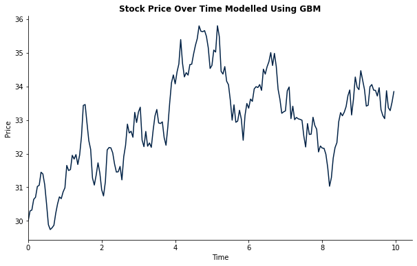

```python
time = np.linspace(0, T, int(T/dt), endpoint = False)

fig, ax = plt.subplots(figsize = (10, 6))

ax.plot(time, stock_price, color = (0, 0.13, 0.27))

ax.set_xlim(left = 0)

ax.set_title("Stock Price Over Time Modelled Using GBM", fontweight = "semibold")
ax.set_xlabel("Time", fontweight = "medium")
ax.set_ylabel("Price", fontweight = "medium")

ax.spines['top'].set_visible(False)
ax.spines['right'].set_visible(False)

plt.show()
```

## 3. Analytical Pricing Methods for European Options

This section is based on ideas found in [1], [3], [6], and [8].

### 3.1 Introduction

In this section we consider European options and the most famous analytical method for pricing them - the BST.

There are two main types of European options, as mentioned in Section 1, namely the call and the put.

A European option is signified by the fact that it grants the holder the ability to exercise the option only at the expiration date of the option, which we refer to as time $T$ in our calculations. This differs, for example, to American options, which allow the holder to exercise at any point up to and including the expiration date.

We define the payoff of a European call at the expiration date $T$ to be $\left(S\left(T\right) - K\right)^{+} = max\left\{S\left(T\right) - K, 0\right\}$, where $S\left(T\right)$ represents the price of the stock at time $T$ and $K$ is the strike price - the predetermined price at which the stock can be bought for at time $T$. Analogously, the payoff of a European put, which grants the holder the ability to sell a stock at time $T$ for $K$, is given by $\left(K - S\left(T\right)\right)^{+} = max\left\{K - S\left(T\right), 0\right\}$.

### 3.2 BST Assumptions

The BST assumes that the underlying stock can be modelled by GBM. This means that the mean rate of return, $\alpha$, and the volatility, $\sigma$, are both assumed to be constant. It further assumes that the underlying stock pays no dividends and has returns that are normally distributed. Finally, the theorem assumes that the option is a European option.

### 3.3 Derivation of the Black-Scholes Partial Differential Equation

We first attempt to derive the Black-Scholes partial differential equation for the price of an option where the underlying security is being modelled by GBM. This derivation follows from attempting to formulate a portfolio $X\left(t\right), t\geq0$ such that $X\left(t\right)$ acts as a hedge for a short position in the option.

We suppose that at time $t$, an agent has a portfolio $X\left(t\right)$ which at each point $t$ holds $\Delta\left(t\right)$ shares of stock, where $\Delta\left(t\right)$ is a random process. The agent then invests the remainder of the portfolio, $X\left(t\right) - \Delta\left(t\right)S\left(t\right)$ in the money market, which pays a constant interest rate of $r$.

We have that the differential $dX\left(t\right)$ of the agent's portfolio at each time $t$ is given by the change in the stock price during that time and the interest on the value of the cash position invested in the money market account.

Thus, we have that

$$\begin{align*} dX\left(t\right) &= \Delta\left(t\right)dS\left(t\right) + r\left(X\left(t\right) - \Delta\left(t\right)S\left(t\right)\right)dt\\ &= \Delta\left(t\right)\left(\alpha\,S\left(t\right)dt + \sigma\,S\left(t\right)dW\left(t\right)\right) + r\left(X\left(t\right) - \Delta\left(t\right)S\left(t\right)\right)dt\\ &= rX\left(t\right) + \Delta\left(t\right)\left(\alpha - r\right)S\left(t\right)dt + \Delta\left(t\right)\sigma\,S\left(t\right)dW\left(t\right). \end{align*}$$

We now calculate $d\left(e^{-rt}X\left(t\right)\right)$ using Itô's Lemma, which represents the differential of the discounted value of the portfolio.

We let $f\left(t, x\right) = e^{-rt}x$ and note that

$$\begin{align*} d\left(e^{-rt}X\left(t\right)\right) &= df\left(t, X\left(t\right)\right)\\ &= f_{t}\left(t, X\left(t\right)\right)dt + f_{x}\left(t, X\left(t\right)\right)dX\left(t\right) + \frac{1}{2}f_{xx}\left(t, X\left(t\right)\right)dX\left(t\right)dX\left(t\right)\\ &= -re^{-rt}X\left(t\right)dt + e^{-rt}dX\left(t\right)\\ &= -re^{-rt}X\left(t\right)dt + e^{-rt}\left(rX\left(t\right) + \Delta\left(t\right)\left(\alpha - r\right)S\left(t\right)dt + \Delta\left(t\right)\sigma\,S\left(t\right)dW\left(t\right)\right)\\ &= \left[-re^{-rt}X\left(t\right) + re^{-rt}X\left(t\right) + e^{-rt}\Delta\left(t\right)\left(\alpha - r\right)S\left(t\right)\right]dt + e^{-rt}\Delta\left(t\right)\sigma\,S\left(t\right)dW\left(t\right)\\ &= \Delta\left(t\right)\left(\alpha - r\right)e^{-rt}S\left(t\right)dt + \Delta\left(t\right)\sigma\,e^{-rt}S\left(t\right)dW\left(t\right). \end{align*}$$

We now consider a European call. As described above, the payoff of a European call at time $T$ is given by $\left(S\left(T\right) - K\right)^{+}$, where $K \geq 0$ is the fixed strike price for the option. It is arguable that the value of a call at any time should depend upon the current time, the current stock price at the time, the strike price, the volatility, and the mean rate of return of the underlying security. Given that only $t$ and $S\left(t\right)$ are variable, we claim that the value of a call can be written as a function of $t$ and $S\left(t\right)$, namely $c\left(t, x\right)$, where $S\left(t\right) = x$. Our goal is to determine this function $c\left(t, x\right)$.

As with the portfolio process $X\left(t\right)$, we begin by computing the differential of $c\left(t, S\left(t\right)\right)$. By Itô's Lemma, we have that

$$\begin{align*} dc\left(t, S\left(t\right)\right) &= c_{t}\left(t, S\left(t\right)\right)dt + c_{x}\left(t, S\left(t\right)\right)dS\left(t\right) + \frac{1}{2}c_{xx}\left(t, S\left(t\right)\right)dS\left(t\right)dS\left(t\right)\\ &= c_{t}\left(t, S\left(t\right)\right)dt + c_{x}\left(t, S\left(t\right)\right)\left(\alpha\,S\left(t\right)dt + \sigma\,S\left(t\right)dW\left(t\right)\right) + \frac{1}{2}c_{xx}\left(t, S\left(t\right)\right)\left(\sigma^2\,S^2\left(t\right)dt\right)\\ &= \left[c_{t}\left(t, S\left(t\right)\right) + \alpha\,S\left(t\right)c_{x}\left(t, S\left(t\right)\right) + \frac{1}{2}\sigma^2\,S^2\left(t\right)c_{xx}\left(t, S\left(t\right)\right)\right]dt + \sigma\,S\left(t\right)c_{x}\left(t, S\left(t\right)\right)dW\left(t\right). \end{align*}$$

Similarly to the above, we now consider the differential of the discounted option price, $e^{-rt}c\left(t, S\left(t\right)\right)$. Taking $f\left(t, x\right) = e^{-rt}x$ and using Itô's Lemma, we have that

$$\begin{align*} d\left(e^{-rt}c\left(t, S\left(t\right)\right)\right) &= df\left(t, c\left(t, S\left(t\right)\right)\right)\\ &= f_{t}\left(t, c\left(t, S\left(t\right)\right)\right)dt + f_{x}\left(t, c\left(t, S\left(t\right)\right)\right)dc\left(t, S\left(t\right)\right) + \frac{1}{2}f_{xx}\left(t, c\left(t, S\left(t\right)\right)\right)dc\left(t, S\left(t\right)\right)dc\left(t, S\left(t\right)\right)\\ &= -re^{-rt}c\left(t, S\left(t\right)\right)dt + e^{-rt}dc\left(t, S\left(t\right)\right)\\ &= -re^{-rt}c\left(t, S\left(t\right)\right)dt + e^{-rt}\left(\left[c_{t}\left(t, S\left(t\right)\right) + \alpha\,S\left(t\right)c_{x}\left(t, S\left(t\right)\right) + \frac{1}{2}\sigma^2\,S^2\left(t\right)c_{xx}\left(t, S\left(t\right)\right)\right]dt + \sigma\,S\left(t\right)c_{x}\left(t, S\left(t\right)\right)dW\left(t\right)\right)\\ &= e^{-rt}\left[-rc\left(t, S\left(t\right)\right) + c_{t}\left(t, S\left(t\right)\right) + \alpha\,S\left(t\right)c_{x}\left(t, S\left(t\right)\right) + \frac{1}{2}\sigma^2\,S^2\left(t\right)c_{xx}\left(t, S\left(t\right)\right)\right]dt + e^{-rt}\sigma\,S\left(t\right)c_{x}\left(t, S\left(t\right)\right)dW\left(t\right). \end{align*}$$

We note that if the constructed hedging portfolio is to truly hedge the value of the option, we must have that $X\left(t\right) = c\left(t, S\left(t\right)\right)$ for all $t\in\left[0,T\right)$. This holds if and only if $e^{-rt}X\left(t\right) = e^{-rt}c\left(t, S\left(t\right)\right)$ for all $t\in\left[0,T\right)$.

This is equivalent to ensuring that $d\left(e^{-rt}X\left(t\right)\right) = d\left(e^{-rt}c\left(t, S\left(t\right)\right)\right)$ for all $t\in\left[0,T\right)$ and $X\left(0\right) = c\left(0, S\left(0\right)\right)$ as then integrating both sides between $0$ and $t$ yields, for all $t\in\left[0,T\right)$,

$$e^{-rt}X\left(t\right) - X\left(0\right) = e^{-rt}c\left(t, S\left(t\right)\right) - c\left(0, S\left(0\right)\right).$$

If we have that $X\left(0\right) = c\left(0, S\left(0\right)\right)$, then we can cancel this term from both sides to get the desired $e^{-rt}X\left(t\right) = e^{-rt}c\left(t, S\left(t\right)\right)$.

We set equal our two expressions for $d\left(e^{-rt}X\left(t\right)\right)$ and $d\left(e^{-rt}c\left(t, S\left(t\right)\right)\right)$ to get the following

$$ \Delta\left(t\right)\left(\alpha - r\right)e^{-rt}S\left(t\right)dt + \Delta\left(t\right)\sigma\,e^{-rt}S\left(t\right)dW\left(t\right) = e^{-rt}\left[-rc\left(t, S\left(t\right)\right) + c_{t}\left(t, S\left(t\right)\right) + \alpha\,S\left(t\right)c_{x}\left(t, S\left(t\right)\right) + \frac{1}{2}\sigma^2\,S^2\left(t\right)c_{xx}\left(t, S\left(t\right)\right)\right]dt \\+ e^{-rt}\sigma\,S\left(t\right)c_{x}\left(t, S\left(t\right)\right)dW\left(t\right). $$

Collecting the like $dW\left(t\right)$ terms gives, for all $t\in\left[0, T\right)$,

$$ \Delta\left(t\right)\sigma\,e^{-rt}S\left(t\right) = e^{-rt}\sigma\,S\left(t\right)c_{x}\left(t, S\left(t\right)\right), $$

which holds if and only if

$$ \Delta\left(t\right) = c_{x}\left(t, S\left(t\right)\right). $$

This is called the delta-hedging rule, which says that at each time $t$, the number of shares, $\Delta\left(t\right)$, held in the stock in the hedging portfolio is equal to the partial derivative of the value of the option with respect to the stock price at that time. We note that the term $c_{x}\left(t, S\left(t\right)\right)$ is called the delta of an option.

Similarly, collecting the like $dt$ terms gives, for all $t\in\left[0,T\right)$,

$$ \Delta\left(t\right)\left(\alpha - r\right)e^{-rt}S\left(t\right) = e^{-rt}\left[-rc\left(t, S\left(t\right)\right) + c_{t}\left(t, S\left(t\right)\right) + \alpha\,S\left(t\right)c_{x}\left(t, S\left(t\right)\right) + \frac{1}{2}\sigma^2\,S^2\left(t\right)c_{xx}\left(t, S\left(t\right)\right)\right]. $$

Substituting $\Delta\left(t\right) = c_{x}\left(t, S\left(t\right)\right)$ and cancelling the $e^{-rt}$ terms gives

$$ \alpha\,S\left(t\right)c_{x}\left(t, S\left(t\right)\right) - rS\left(t\right)c_{x}\left(t, S\left(t\right)\right) = -rc\left(t, S\left(t\right)\right) + c_{t}\left(t, S\left(t\right)\right) + \alpha\,S\left(t\right)c_{x}\left(t, S\left(t\right)\right) + \frac{1}{2}\sigma^2\,S^2\left(t\right)c_{xx}\left(t, S\left(t\right)\right). $$

Finally, cancelling the $\alpha\,S\left(t\right)c_{x}\left(t, S\left(t\right)\right)$ terms on both sides and rearranging, we obtain, for all $t\in\left[0,T\right)$,

$$ rc\left(t, S\left(t\right)\right) = c_{t}\left(t, S\left(t\right)\right) + rS\left(t\right)c_{x}\left(t, S\left(t\right)\right) + \frac{1}{2}\sigma^2\,S^2\left(t\right)c_{xx}\left(t, S\left(t\right)\right). $$

Restating the above, using the substitution $S\left(t\right) = x$, we obtain the Black-Scholes Partial Differential Equation ("PDE"), for all $t\in\left[0,T\right), x\geq 0$:

$$ rc\left(t, x\right) = c_{t}\left(t, x\right) + rxc_{x}\left(t, x\right) + \frac{1}{2}\sigma^2\,x^2\,c_{xx}\left(t, x\right), $$

with terminal condition $c\left(T, x\right) = \left(x - K\right)^{+}$.

### 3.4 Solving the Black-Scholes Partial Differential Equation

We start with the following substitutions

$$ \tau = \left(T-t\right)\frac{1}{2}\sigma^2,\\ y = \log\left(\frac{x}{K}\right), $$

where $\log$ is the natural logarithm.

We then let $c\left(t, x\right) = Kv\left(\tau, y\right)$ for some function $v$.

We note that

$$\begin{align*} \frac{dc}{dt} &= K\frac{dv}{d\tau}\frac{d\tau}{dt}\\ &= -\frac{K\sigma^2}{2}\frac{dv}{d\tau}, \end{align*}$$$$\begin{align*} \frac{dc}{dx} &= K\frac{dv}{dy}\frac{dy}{dx} \\ &= \frac{K}{x}\frac{dv}{dy}, \end{align*}$$

and thus,

$$\begin{align*} \frac{d^2c}{dx^2} &= \frac{d}{dx}\left(\frac{K}{x}\frac{dv}{dy}\right)\\ &= -\frac{K}{x^2}\frac{dv}{dy} + \frac{K}{x^2}\frac{dv^2}{dy^2}. \end{align*}$$

These substitutions give us the terminal condition

$$\begin{align*} c\left(T, x\right) &= \left(x - K\right)^{+}\\ &= \left(Ke^{y} - K\right)^{+}. \end{align*}$$

We also note that $c\left(T, x\right) = Kv\left(0, y\right)$ which implies that $v\left(0, y\right) = \left(e^{y} - 1\right)^{+}$.

Taking our derivatives above and substituting them into the Black-Scholes PDE, we get

$$ -\frac{K\sigma^2}{2}v_{\tau} + \frac{\left(Ke^y\right)^2\sigma^2}{2}\left(-\frac{K}{\left(Ke^y\right)^2}v_{y} + \frac{K}{\left(Ke^y\right)^2}v_{yy}\right) + r\left(Ke^y\right)\left(\frac{K}{Ke^y}v_{y}\right) - rKv = 0, $$

which simplifies to

$$ -\frac{\sigma^2}{2}v_{\tau} + \frac{\sigma^2}{2}\left(v_{yy} - v_{y}\right) + rv_{y} - rv = 0. $$

We let $k = \frac{r}{\frac{\sigma^2}{2}}$, substitute this into our equation, and rearrange to obtain

$$ v_{\tau} = v_{yy} + \left(k-1\right)v_{y} - kv. $$

This leaves the equation in a much simpler form with a single parameter $k$.

We now let $v\left(\tau, y\right) = e^{\alpha{y} + \beta\tau}u\left(\tau, y\right)$ for some function $u$.

We have the following derivatives:

$$ v_{\tau} = \beta{e}^{\alpha{y}+\beta\tau}u + e^{\alpha{y}+\beta\tau}u_{\tau},\\ v_{y} = \alpha{e}^{\alpha{y}+\beta\tau}u + e^{\alpha{y}+\beta\tau}u_{y},\\ v_{yy} = \alpha^2{e}^{\alpha{y}+\beta\tau}u + 2\alpha{e}^{\alpha{y}+\beta\tau}u_{y} + {e}^{\alpha{y}+\beta\tau}u_{yy}. $$

Substituting these derivatives in and simplifying our equation gives us the following:

$$ u_{\tau} = u_{yy} + u_{y}\left(k - 1 + 2\alpha\right) + u\left(\alpha^2 + k\alpha - \alpha - k - \beta\right). $$

Thus, we choose $\alpha = -\frac{\left(k - 1\right)}{2}$ and $\beta = \alpha^2 + \left(k - 1\right)\alpha - k = -\frac{\left(k+1\right)^2}{4}$ to ensure the coefficients of $u_{y}$ and $u$ are both $0$.

This gives us the following equation, which is the Heat Equation:

$$ u_{\tau} = u_{yy}, $$

with the initial condition transformed into the following:

$$ u\left(0, y\right) = \left(\exp\left\{\frac{\left(k + 1\right)}{2}y\right\} - \exp\left\{\frac{\left(k - 1\right)}{2}y\right\}\right)^{+}. $$

We have the following standard solution for the Heat Equation, which we will transform back into a solution for the Black-Scholes PDE:

$$ u\left(\tau, y\right) = \frac{1}{2\sqrt{\pi\tau}}\int_{-\infty}^{\infty}u_{0}\left(s\right)\exp\left\{\frac{-\left(y-s\right)^2}{4\tau}\right\}ds. $$

We let $z = \frac{\left(s - y\right)}{\sqrt{2\tau}}$, which gives the following transformation

$$\begin{align*} u\left(\tau, y\right) &= \frac{1}{\sqrt{2\pi}}\int_{-\infty}^{\infty}u_{0}\left(z\sqrt{2\tau} + y\right)\exp\left\{\frac{-z^2}{2}\right\}dz\\ &= \frac{1}{\sqrt{2\pi}}\int_{-\infty}^{\infty}\left(\exp\left\{\frac{1}{2}\left(k+1\right)\left(y + z\sqrt{2\tau}\right)\right\} - \exp\left\{\frac{1}{2}\left(k-1\right)\left(y + z\sqrt{2\tau}\right)\right\}\right)^{+}\exp\left\{\frac{-z^2}{2}\right\}dz\\ &= \frac{1}{\sqrt{2\pi}}\int_{-\frac{y}{\sqrt{2\tau}}}^{\infty}\left(\exp\left\{\frac{1}{2}\left(k+1\right)\left(y + z\sqrt{2\tau}\right)\right\} - \exp\left\{\frac{1}{2}\left(k-1\right)\left(y + z\sqrt{2\tau}\right)\right\}\right)\exp\left\{\frac{-z^2}{2}\right\}dz\\ &= \frac{1}{\sqrt{2\pi}}\int_{-\frac{y}{\sqrt{2\tau}}}^{\infty}\exp\left\{\frac{1}{2}\left(k+1\right)\left(y + z\sqrt{2\tau}\right)\right\}\exp\left\{\frac{-z^2}{2}\right\}dz - \frac{1}{\sqrt{2\pi}}\int_{-\frac{y}{\sqrt{2\tau}}}^{\infty}\exp\left\{\frac{1}{2}\left(k-1\right)\left(y + z\sqrt{2\tau}\right)\right\}\exp\left\{\frac{-z^2}{2}\right\}dz\\ &= I_{1} - I_{2}. \end{align*}$$

We note that, by completing the square in the exponent, we can write $I_{1}$ as

$$\begin{align*} I_{1} &= \frac{1}{\sqrt{2\pi}}\int_{-\frac{y}{\sqrt{2\tau}}}^{\infty}\exp\left\{\frac{1}{2}\left(k+1\right)\left(y + z\sqrt{2\tau}\right)\right\}\exp\left\{\frac{-z^2}{2}\right\}dz\\ &= \frac{1}{\sqrt{2\pi}}\int_{-\frac{y}{\sqrt{2\tau}}}^{\infty}\exp\left\{\frac{1}{2}\left(k+1\right)\left(y + z\sqrt{2\tau}\right)-\frac{z^2}{2}\right\}dz\\ &= \frac{\exp\left\{\frac{1}{2}\left(k + 1\right)y\right\}}{\sqrt{2\pi}}\int_{-\frac{y}{\sqrt{2\tau}}}^{\infty}\exp\left\{-\frac{1}{2}\left(z^2 - z\left(k+1\right)\sqrt{2\tau}\right)\right\}dz\\ &= \frac{\exp\left\{\frac{1}{2}\left(k + 1\right)y\right\}}{\sqrt{2\pi}}\int_{-\frac{y}{\sqrt{2\tau}}}^{\infty}\exp\left\{-\frac{1}{2}\left[\left(z - \frac{1}{2}\left(k + 1\right)\sqrt{2\tau}\right)^2 - \frac{1}{2}\tau\left(k + 1\right)^2\right]\right\}dz\\ &= \frac{\exp\left\{\frac{1}{2}\left(k + 1\right)y + \frac{1}{4}\left(k + 1\right)^2\tau\right\}}{\sqrt{2\pi}}\int_{-\frac{y}{\sqrt{2\tau}}}^{\infty}\exp\left\{-\frac{1}{2}\left(z - \frac{1}{2}\left(k + 1\right)\sqrt{2\tau}\right)^2\right\}dz. \end{align*}$$

We let $\omega = z - \frac{1}{2}\left(k + 1\right)\sqrt{2\tau}$, which gives the following transformation

$$\begin{align*} I_{1} &= \frac{\exp\left\{\frac{1}{2}\left(k + 1\right)y + \frac{1}{4}\left(k + 1\right)^2\tau\right\}}{\sqrt{2\pi}}\int_{-\frac{y}{\sqrt{2\tau}} - \frac{1}{2}\left(k + 1\right)\sqrt{2\tau}}^{\infty}\exp\left\{-\frac{1}{2}\omega^2\right\}d\omega\\ &= \frac{\exp\left\{\frac{1}{2}\left(k + 1\right)y + \frac{1}{4}\left(k + 1\right)^2\tau\right\}}{\sqrt{2\pi}}\int_{-\infty}^{\frac{y}{\sqrt{2\tau}} + \frac{1}{2}\left(k + 1\right)\sqrt{2\tau}}\exp\left\{-\frac{1}{2}\omega^2\right\}d\omega\\ &= \exp\left\{\frac{1}{2}\left(k + 1\right)y + \frac{1}{4}\left(k + 1\right)^2\tau\right\}N\left(d_{+}\right), \end{align*}$$

where

$$ N\left(d\right) = \frac{1}{\sqrt{2\pi}}\int_{-\infty}^{d}\exp\left\{-\frac{1}{2}z^2\right\}dz,$$

and

$$ d_{+} = \frac{y}{\sqrt{2\tau}} + \frac{1}{2}\left(k + 1\right)\sqrt{2\tau}. $$

Similarly, we can calculate $I_{2}$ to get

$$ I_{2} = \exp\left\{\frac{1}{2}\left(k - 1\right)y + \frac{1}{4}\left(k - 1\right)^2\tau\right\}N\left(d_{-}\right), $$

where

$$ d_{-} = \frac{y}{\sqrt{2\tau}} + \frac{1}{2}\left(k - 1\right)\sqrt{2\tau}. $$

Thus, substituting the values for $I_{1}$ and $I_{2}$, we have that

$$ u\left(\tau, y\right) = \exp\left\{\frac{1}{2}\left(k + 1\right)y + \frac{1}{4}\left(k + 1\right)^2\tau\right\}N\left(d_{+}\right) - \exp\left\{\frac{1}{2}\left(k - 1\right)y + \frac{1}{4}\left(k - 1\right)^2\tau\right\}N\left(d_{-}\right). $$

Then, given our chosen values of $\alpha$ and $\beta$, we have that

$$\begin{align*} v\left(\tau, y\right) &= e^{\alpha{y} + \beta\tau}u\left(\tau, y\right)\\ &= e^{-\frac{\left(k - 1\right)}{2}y \,- \frac{\left(k + 1\right)^2}{4}\tau}u\left(\tau, y\right)\\ &= \exp\left\{-\frac{1}{2}\left(k - 1\right)y \,- \frac{1}{4}\left(k + 1\right)^2\tau\right\}\cdot\left[\exp\left\{\frac{1}{2}\left(k + 1\right)y + \frac{1}{4}\left(k + 1\right)^2\tau\right\}N\left(d_{+}\right) - \exp\left\{\frac{1}{2}\left(k - 1\right)y + \frac{1}{4}\left(k - 1\right)^2\tau\right\}N\left(d_{-}\right)\right]\\ &= e^{y}N\left(d_{+}\right) - e^{-k\tau}N\left(d_{-}\right). \end{align*}$$

Substituting our values for $y$ and $\tau$, we get

$$\begin{align*} v\left(\tau, y\right) &= e^{\log{\frac{x}{K}}}N\left(d_{+}\right) - e^{-\frac{1}{2}k\sigma^2\left(T - t\right)}N\left(d_{-}\right)\\ &= \frac{x}{K}N\left(d_{+}\right) - e^{-\frac{1}{2}k\sigma^2\left(T - t\right)}N\left(d_{-}\right). \end{align*}$$

Applying the transformations to $d_{+}$ and $d_{-}$, we get

$$ d_{\pm} = \frac{1}{\sigma\sqrt{T - t}}\left[\log\left(\frac{x}{K}\right) + \frac{1}{2}\sigma^2\left(k \pm 1\right)\left(T - t\right)\right]. $$

Given $r = \frac{1}{2}k\sigma^2$, we have that

$$ v\left(\tau, y\right) = \frac{x}{K}N\left(d_{+}\right) - e^{-r\left(T - t\right)}N\left(d_{-}\right),\\ d_{\pm} = \frac{1}{\sigma\sqrt{T - t}}\left[\log\left(\frac{x}{K}\right) + \left(r \pm \frac{1}{2}\sigma^2\right)\left(T - t\right)\right]. $$

Finally, we consider our original substitution to get

$$\begin{align*} c\left(t, x\right) &= Kv\left(\tau, y\right)\\ &= K\left(\frac{x}{K}N\left(d_{+}\right) - e^{-r\left(T - t\right)}N\left(d_{-}\right)\right)\\ &= xN\left(d_{+}\right) - Ke^{-r\left(T - t\right)}N\left(d_{-}\right), \end{align*}$$

which is the solution to the Black-Scholes equation, where

$$ d_{\pm} = \frac{1}{\sigma\sqrt{T - t}}\left[\log\left(\frac{x}{K}\right) + \left(r \pm \frac{1}{2}\sigma^2\right)\left(T - t\right)\right]. $$

### 3.5 Pricing European Calls

We now proceed to price European Calls using the function $c(t, x)$.

```python
from scipy.stats import norm
```

```python
#We define d_plus, d_minus, and euro_call_price as per the formulas derived in Section 3.4

def d_plus(sigma, T, t, x, K, r):
    return (1/(sigma * np.sqrt(T-t)))*(np.log(x/K) + (r + (sigma**2)/2)*(T-t))

def d_minus(sigma, T, t, x, K, r):
    return (1/(sigma * np.sqrt(T-t)))*(np.log(x/K) + (r - (sigma**2)/2)*(T-t))

def euro_call_price(sigma, T, t, x, K, r):
    return x*norm.cdf(d_plus(sigma, T, t, x, K, r), loc = 0, scale = 1) - K*np.exp(-r*(T-t))*norm.cdf(d_minus(sigma, T, t, x, K, r), loc = 0, scale = 1)
```

```python
print(euro_call_price(sigma = 0.05, T = 10, t = 4, x = 40, K = 50, r = 0.05))
```

```
3.7184815043165536
```

We start by plotting the stock price, simulated by GBM, against the corresponding European call price with a fixed strike price $K$, fixed volatility $\sigma$, fixed interest rate $r$.

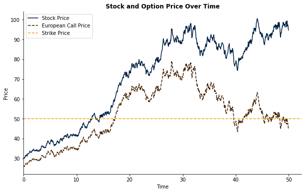

```python
S_0 = 30
sigma = 0.05
alpha = 0.02
dt = 0.05
T = 50
K = 50
r = 0.05

#We generate stock prices, times and a list for the European option prices before populating it using the Black-Scholes equation
stock_price_list = simulate_gbm(S_0, sigma, alpha, dt, T)
time_list = np.linspace(0, T, int(T/dt), endpoint = False)
euro_call_price_list = np.zeros(int(T/dt))

for i in range(len(stock_price_list)):
    euro_call_price_list[i] = euro_call_price(sigma, T, time_list[i], stock_price_list[i], K, r)

#We define a function for plotting the two components
def plot_option_stock(time, stock_price, option_price, K):
    plt.clf()

    fig, ax = plt.subplots(figsize = (10, 6))

    ax.plot(time, stock_price, color = (0, 0.13, 0.27), label = "Stock Price")
    ax.plot(time, option_price, color = (0.27, 0.13, 0), ls = "--", label = "European Call Price")
    ax.axhline(y = K, color = (0.95, 0.65, 0.07), label = "Strike Price", ls = "--")

    ax.set_xlim(left = 0)

    ax.set_title("Stock and Option Price Over Time", fontweight = "semibold")
    ax.set_xlabel("Time", fontweight = "medium")
    ax.set_ylabel("Price", fontweight = "medium")

    ax.legend()

    ax.spines["top"].set_visible(False)
    ax.spines["right"].set_visible(False)

    plt.show()

plot_option_stock(time_list, stock_price_list, euro_call_price_list, K)
```

We note that the price of the European call appears to fluctuate as the price of the underlying security fluctuates, as we would expect.

It also appears that as time progresses, options seem to lose value. This is known as option decay or 'theta'. It represents the rate at which an option loses money on account of time. It is one of the 'Greeks' - a series of metrics that measure the sensitivity of an option price. Delta, which we saw earlier, is another of the Greeks.

We note that since theta represents the rate at which the price of the option decreases due to time, this is equivalent to $c_{t}\left(t, x\right)$.

Thus, we have that differentiating the Black-Scholes formula $c\left(t, x\right)$ with respect to time $t$ gives

$$ c_{t}\left(t, x\right) = -rKe^{-r\left(T-t\right)}N\left(d_{-}\right) - \frac{\sigma{x}}{2\sqrt{T-t}}N'\left(d_{+}\right). $$

We can show the effect of theta in two ways.

Firstly, we plot the price of the stock and the option on the same scale, however we fix everything but the time $t$, including the stock price.

This can be achieved by setting the mean rate of return, $\alpha = 0$, and by making the volatility very small, $\sigma = 1\mathrm{e}{-24}$, in our model of the stock price.

We note that we do not set $\sigma = 0$ because it would result in an error in the calculation of $d_{\pm}$.

[figure not shown]

```python
small_sigma = 1*10**-24
zero_alpha = 0
K1 = 10
T = 100

#We generate stock prices, times and a list for the European option prices before populating it using the Black-Scholes equation
fixed_stock_price_list = simulate_gbm(S_0, small_sigma, zero_alpha, dt, T)
fixed_time_list = np.linspace(0, T, int(T/dt), endpoint = False)
fixed_euro_call_price_list = np.zeros(int(T/dt))

for i in range(len(fixed_stock_price_list)):
    fixed_euro_call_price_list[i] = euro_call_price(small_sigma, T, fixed_time_list[i], fixed_stock_price_list[i], K1, r)

plot_option_stock(fixed_time_list, fixed_stock_price_list, fixed_euro_call_price_list)
```

We can see this mathematically by considering $c(t, x)$ for small $\sigma$ as $t \xrightarrow {}T$.

Firstly, we note that, as $\sigma \xrightarrow {} 0$, we have that $d_{\pm} \xrightarrow {} \infty$ and thus $N(d_{\pm}) \xrightarrow {} 1$. Hence, for very small $\sigma$, we have that

$$ c(t, x) \approx x - Ke^{-r(T-t)}. $$

Given $x\gt0$ and $K\ge0$, we have that for $r\ge0$ that the price of the option decays exponentially as $t \xrightarrow {}T$, with $c(T, x) = x - K$.

We now consider plotting theta on top of our graph with the stock price and the European call price to see how it fluctuates as the price of the underlying security, and thus the price of the European call, fluctuates.

```python
def euro_call_theta(sigma, T, t, x, K, r):
    return -r*K*np.exp(-r*(T-t))*norm.cdf(d_minus(sigma, T, t, x, K, r), loc = 0, scale = 1) - ((sigma*x)/(2*np.sqrt(T-t)))*norm.pdf(d_plus(sigma, T, t, x, K, r), loc = 0, scale = 1)
```

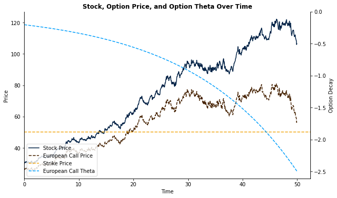

```python
S_0 = 30
sigma = 0.05
alpha = 0.02
dt = 0.05
T = 50
K = 50
r = 0.05

stock_price_list = simulate_gbm(S_0, sigma, alpha, dt, T)
time_list = np.linspace(0, T, int(T/dt), endpoint = False)
euro_call_price_list = np.zeros(int(T/dt))

for i in range(len(stock_price_list)):
    euro_call_price_list[i] = euro_call_price(sigma, T, time_list[i], stock_price_list[i], K, r)

euro_call_theta_list = np.zeros(int(T/dt))

for i in range(len(stock_price_list)):
    euro_call_theta_list[i] = euro_call_theta(sigma, T, time_list[i], stock_price_list[i], K, r)

plt.clf()

fig, ax1 = plt.subplots(figsize = (10, 6))

line1,= ax1.plot(time_list, stock_price_list, color = (0, 0.13, 0.27), label = "Stock Price")
line2,= ax1.plot(time_list, euro_call_price_list, color = (0.27, 0.13, 0), ls = "--", label = "European Call Price")
line3= ax1.axhline(y = K, color = (0.95, 0.65, 0.07), label = "Strike Price", ls = "--")

ax2 = ax1.twinx()
line4,= ax2.plot(time_list, euro_call_theta_list, color = (0, 0.62, 0.99), ls = "--", label = "European Call Theta")

ax1.set_xlim(left = 0)
ax2.set_ylim(top = 0)

ax1.set_title("Stock, Option Price, and Option Theta Over Time", fontweight = "semibold")
ax1.set_xlabel("Time", fontweight = "medium")
ax1.set_ylabel("Price", fontweight = "medium")
ax2.set_ylabel("Option Decay", fontweight = "medium")

handles = [line1, line2, line3, line4]
labels = [line.get_label() for line in handles]
ax1.legend(handles, labels, loc = "lower left")

ax1.spines["top"].set_visible(False)
ax2.spines["top"].set_visible(False)

plt.show()
```

### 3.6 Conclusion

In this section, we have considered how to use closed-ended, analytical methods to price European calls. We started with the BST and the assumptions required for it to hold before deriving the Black-Scholes PDE. We then solved this equation by transforming it into the well-known Heat Equation.

This allowed us to calculate the price of an option as time progressed, before we briefly touched on the idea of theta decay - which is represented by the derivative of the price of the option with respect to time and reflects how the value of the option will decrease with time, given theta is always negative.

In the next section, we will consider an alternative approach to pricing an option - a numerical method using Monte-Carlo simulations.

## 4. Numerical Methods for Pricing European Options

This section is based on ideas found in [2] and [7].

### 4.1 Introduction

In this section, we shall employ the Monte-Carlo method to estimate the price of a European call at time $t = 0$.

Monte-Carlo simulations are often used to price derivatives, however we note this is often as a method of last resort, if there are no analytical and closed-ended solutions available. This is due to the method being an estimation, resulting in inaccuracies and the method's reliance upon the generation of a large number of samples, which increases processing time. However, when there are no closed-ended solutions available, the Monte-Carlo method becomes very useful.

### 4.2 The Monte-Carlo Method

The Monte-Carlo method relies upon repeated simulations in order to estimate probabilities or values. In the context of pricing European options, we have assumed that the underlying security can be modelled by GBM, which we considered in Section 2. We can therefore simulate $n$ different GBM paths from time $t$ to time $T$ and calculate the payoff of those paths at time $T$ using the formula $c\left(T, S\left(T\right)\right) = \left(S\left(T\right) - K\right)^{+}$, where $K$ is the strike price. We can then average this payoff and discount it back by $e^{-rT}$ to calculate its present value, assuming a risk-neutral position.

The Monte-Carlo method uses the Law of Large Numbers, which suggests that as $n \rightarrow \infty$, the average payoff will approach the true payoff of such an option. And thus, by discounting it back to the present day, we are calculating the amount of money we could otherwise invest in the money market, at an interest rate of $r$, to be able to successfully hedge the option at time $T$, which we described as the price of the option, when considering the Black-Scholes PDE.

Therefore, we start by writing a function that can simulate $n$ paths of GBM.

```python
def simulate_gbm_paths(paths, S_0, sigma, alpha, dt, T):

    simulated_paths = np.zeros((paths, int(T/dt)))

    for path in range(paths):
        simulated_paths[path] = simulate_gbm(S_0, sigma, alpha, dt, T)

    return simulated_paths
```

Below, we plot $10$ simulated paths for $S(0) = 30$ and $T = 10$ to show this idea of repeated simulation.

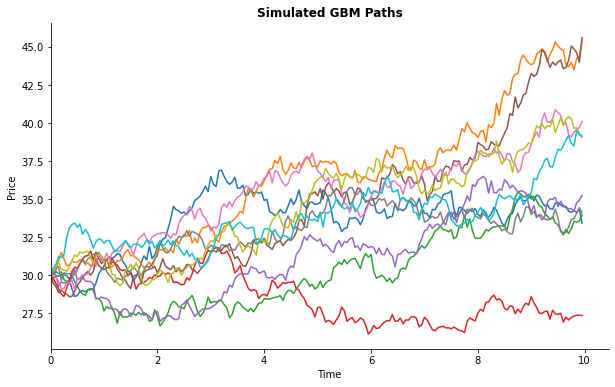

```python
S_0 = 30
sigma = 0.05
alpha = 0.02
dt = 0.05
T = 10
paths = 10

simulated_paths = simulate_gbm_paths(paths, S_0, sigma, alpha, dt, T)
time_list = np.linspace(0, T, int(T/dt), endpoint = False)

plt.clf()
fig, ax = plt.subplots(figsize=(10, 6))

for path in simulated_paths:
    ax.plot(time_list, path)

ax.set_xlim(left = 0)

ax.set_title("Simulated GBM Paths", fontweight = "semibold")
ax.set_xlabel("Time", fontweight = "medium")
ax.set_ylabel("Price", fontweight = "medium")

ax.spines["top"].set_visible(False)
ax.spines["right"].set_visible(False)

plt.show()
```

We then want to be able to generate the payoffs of the paths we generate.

```python
def euro_call_payoffs(paths, simulated_paths, K):
    payoffs = np.zeros(paths)

    idx = 0

    for path in simulated_paths:
        payoffs[idx] = max(path[-1] - K, 0)
        idx += 1

    return payoffs
```

### 4.3 Pricing European Options With the Monte-Carlo Method

We now write a function that combines all of these functions together. First it needs to generate $n$ paths under GBM. Then it will calculate the payoff at time $T$ for each of those paths, given strike price $K$. Finally, the function will take an average of these payoffs and discount this back to get the price of the call.

```python
def mc_euro_call_price(paths, S_0, sigma, alpha, dt, T, K, r):
    simulated_stock_paths = simulate_gbm_paths(paths, S_0, sigma, alpha, dt, T)
    euro_call_payoffs_list = euro_call_payoffs(paths, simulated_stock_paths, K)
    average_payoff = np.average(euro_call_payoffs_list)
    return np.exp(-r*T)*average_payoff
```

We then test our function and see the Monte-Carlo method is providing a price for the function.

```python
S_0 = 30
sigma = 0.05
alpha = 0.05
dt = 0.05
T = 50
paths = 100
r = alpha #We assume a risk-neutral position
K = 200

euro_call_mc_price = mc_euro_call_price(paths, S_0, sigma, alpha, dt, T, K, r)

print("The price of the European call as per the Monte-Carlo method is {price:.2f}.".format(price = euro_call_mc_price))
```

```
The price of the European call as per the Monte-Carlo method is 14.42.
```

## 5. Comparing Analytical & Numerical Methods for Pricing European Options

We now consider the two methods we have arrived at for pricing European options - specifically European calls, with the pricing of European puts being analogous.

We first demonstrate that the estimated value calculated by the Monte-Carlo method is indeed close to the analytical solution provided by the Black-Scholes equation.

```python
bs_price = euro_call_price(sigma, T, 0, S_0, K, r)
print("The price of the European call as per the Black-Scholes equation is {price:.2f}.".format(price = bs_price))

mc_price = mc_euro_call_price(paths, S_0, sigma, alpha, dt, T, K, r)
print("The price of the European call as per the Monte-Carlo method is {price:.2f}.".format(price = mc_price))

difference = abs(mc_price - bs_price)
pct_difference = difference / bs_price

print("The absolute difference in price of the European call between the two methods is {diff:.2f}, which reflects ~{pct:.1%}".format(diff = difference, pct = pct_difference))
```

```
The price of the European call as per the Black-Scholes equation is 13.72.
The price of the European call as per the Monte-Carlo method is 14.46.
The absolute difference in price of the European call between the two methods is 0.73, which reflects ~5.3%
```

We note that the accuracy of the Monte-Carlo method above varies, with most estimates being within a $10\%$ range of the price generated by the Black-Scholes formula.

To improve the accuracy of the Monte-Carlo method, we can increase $n$. Below, we show how the price generated by the Monte-Carlo method varies as we increase $n$ with respect to the price generated by the Black-Scholes formula.

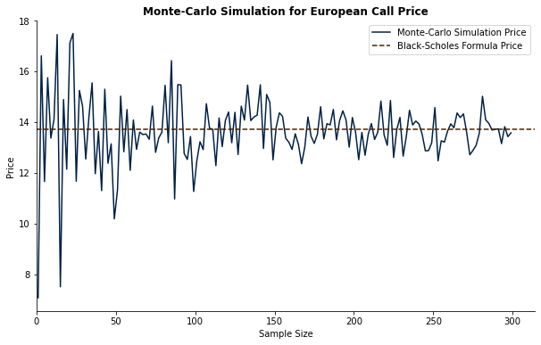

```python
sample_size_list = np.array(range(1,301,2))

mc_prices = np.zeros(len(sample_size_list))

for i in range(len(sample_size_list)):
    mc_prices[i] = mc_euro_call_price(sample_size_list[i], S_0, sigma, alpha, dt, T, K, r)

euro_price = euro_call_price(sigma, T, 0, S_0, K, r)

plt.clf()
fig, ax = plt.subplots(figsize=(10, 6))

ax.plot(sample_size_list, mc_prices, color = (0, 0.13, 0.27), label = "Monte-Carlo Simulation Price")
ax.axhline(y = euro_price, color = (0.27, 0.13, 0), label = "Black-Scholes Formula Price", ls = "--")

ax.set_xlim(left = 0)

ax.set_title("Monte-Carlo Simulation for European Call Price", fontweight = "semibold")
ax.set_xlabel("Sample Size", fontweight = "medium")
ax.set_ylabel("Price", fontweight = "medium")

ax.spines["top"].set_visible(False)
ax.spines["right"].set_visible(False)

ax.legend()

plt.show()
```

We see that as $n$ increases, the price generated by the Monte-Carlo method tends toward the closed-ended price calculated using the Black-Scholes equation, with the variation appearing to decrease as $n$ increases, as expected.

Notably, the Monte-Carlo method is a slower, less accurate approach to pricing and would not be used in practicality if there were a simple closed-ended solution. We note that the time-complexity of the Monte-Carlo we have written is $O(n)$ as can be seen in the below exercise.

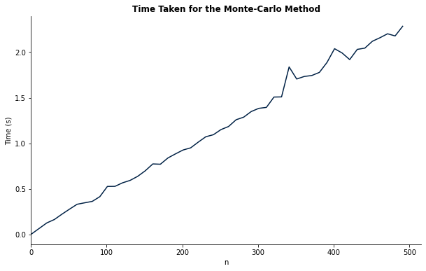

```python
import time

sample_size_list = np.array(range(1, 501, 10))
time_taken_list = np.zeros(len(sample_size_list))

for i in range(len(sample_size_list)):
    start_time = time.time()
    mc_price = mc_euro_call_price(sample_size_list[i], S_0, sigma, alpha, dt, T, K, r)
    end_time = time.time()

    time_taken = end_time - start_time
    time_taken_list[i] = time_taken


plt.clf()

fig, ax = plt.subplots(figsize=(10, 6))

ax.plot(sample_size_list, time_taken_list, color = (0, 0.13, 0.27))

ax.set_title("Time Taken for the Monte-Carlo Method", fontweight = "semibold")

ax.set_xlabel("n", fontweight = "medium")
ax.set_ylabel("Time (s)", fontweight = "medium")

ax.set_xlim(left = 0)

ax.spines["top"].set_visible(False)
ax.spines["right"].set_visible(False)

plt.show()
```

This differs in comparison to the Black-Scholes equation, which can compute in $O(1)$ time. Plotting the time taken between the two quickly shows how the Black-Scholes method is superior from a time-complexity perspective.

[figure not shown]

```python
sample_size_list = np.array(range(1, 302, 20))
mc_time_taken_list = np.zeros(len(sample_size_list))
bs_time_taken_list = np.zeros(len(sample_size_list))

for i in range(len(sample_size_list)):
    mc_start_time = time.time()
    mc_price = mc_euro_call_price(sample_size_list[i], S_0, sigma, alpha, dt, T, K, r)
    mc_end_time = time.time()

    mc_time_taken = mc_end_time - mc_start_time
    mc_time_taken_list[i] = mc_time_taken

    bs_start_time = time.time()
    bs_price = euro_call_price(sigma, T, 0, S_0, K, r)
    bs_end_time = time.time()

    bs_time_taken = bs_end_time - bs_start_time
    bs_time_taken_list[i] = bs_time_taken


plt.clf()

fig, ax = plt.subplots(figsize=(10, 6))

ax.plot(sample_size_list, mc_time_taken_list, color = (0, 0.13, 0.27), label = "Monte-Carlo Method")
ax.plot(sample_size_list, bs_time_taken_list, color = (0.27, 0.13, 0), label = "Black-Scholes Equation")

ax.set_title("Time Taken for European Call Pricing Methods", fontweight = "semibold")

ax.set_xlabel("n", fontweight = "medium")
ax.set_ylabel("Time (s)", fontweight = "medium")

ax.set_xlim(left = 0)

ax.spines["top"].set_visible(False)
ax.spines["right"].set_visible(False)

ax.legend()

plt.show()
```

Clearly, the Black-Scholes, and closed-ended analytical solutions in general, is a superior method for calculating the price of a European option, given it is more accurate and faster.

However, we note that Monte-Carlo solutions still have a large role to play in the event of pricing more complicated financial instruments that do not have an easy-to-calculate or known analytical solution.

## 6. Analytical Pricing Methods for Barrier Options

This section is based on ideas found in [8].

### 6.1 Introduction

We now consider a more exotic option - a Barrier option. An exotic option is an option that is considered more complex than "vanilla" options, such as European and American options. The complexity of the exotic option is usually with regards to the calculation of the payoff, which in turn can increase the difficulty of formulating an analytical, closed-ended solution for pricing the option.

A Barrier option is a form of exotic option and is path-dependent, meaning that the payoff of the option depends upon the previous values of the underlying asset up until the point of expiry. A Barrier option involves a pre-agreed barrier $B$ that influences the value of the option should the underlying security breakthrough this barrier.

There are four main types of Barrier options, with each type having a call and a put variant:

1. Up-and-out;
2. Down-and-out;
3. Up-and-in, and;
4. Down and in.

The up-and-out option means that should the price of the underlying asset breakthrough and be greater than $B$ for some $t \in [0, T)$, then the option is said to have been "knocked-out" and the value of the option is henceforth $0$, even if the price of the underlying asset then retreats below $B$. A down-and-out works in a similar manner except the price of the underlying asset must fall below $B$ in price to be considered knocked-out.

On the other hand, an up-and-in Barrier option is said to have been "knocked-in" once the underlying asset reaches and then breaches above $B$, with the option only having a non-zero value following this point in time, with a value of $0$ until that point. Similarly, down-and-in Barrier options have value $0$ up until the point at which the underlying security goes below $B$ in value, at which point the option is knocked-in and now can have a non-zero payoff.

In this section we shall consider an up-and-out call with barrier $B$, but the findings hold analogously for the other types from both a call and put perspective.

### 6.2 The Black-Scholes Equation & Solution for Barrier Options

In this section, we shall state the modified Black-Scholes equation in the context of a Barrier option, before providing the solution $v\left(t, x\right)$, where $t$ is the time such that $t \in \left[0, T\right)$ and $S\left(t\right) = x$ is the underlying stock price at time $t$.

If we let $v\left(t, x\right)$ represent the price at time $t$ of an up-and-out call that has not been knocked-out at time $t$ and $S\left(t\right) = x$, then we have that this function satisfies the Black-Scholes PDE with some modified conditions within a certain space. That is namely the following PDE,

$$ rv\left(t, x\right) = v_{t}\left(t, x\right) + rxv_{x}\left(t, x\right) + \frac{1}{2}\sigma^2\,x^2\,v_{xx}\left(t, x\right), $$

in the rectangle $\left\{\left(t, x\right); 0 \leq t \lt T, 0 \leq x \lt B\right\}$, where

$$\begin{align*} v\left(t, 0\right) &= 0, \hspace{1cm} t\in \left[0, T\right],\\ v\left(t, B\right) &= 0, \hspace{1cm} t\in\left[0, T\right),\\ v\left(T, x\right) &= \left(x - K\right)^{+}, \hspace{1cm} x\in\left[0, B\right]. \end{align*}$$

The three conditions can be understood as follows. If the price $x$ of the underlying security reaches or starts at $0$, then it remains at $0$, thus meaning the payoff of the call will be $0$. Condition two comes from the fact that if the price of the underlying asset reaches $B$ at any time, then the non-zero quadratic variation of the underlying asset means it will rise above $B$ infinitely many times almost surely as it oscillates about $B$. This can be thought of as the underlying asset being on the verge of being knocked-out. Finally, the third condition states that the payoff of the call at time $T$ is equivalent to that of a European call, under the condition that $x$ is between $0$ and $B$,

It is worth noting that the function is continuous everywhere except at the corner of the domain at the point $\left(T, B\right)$, where the underlying asset reaches a price of $B$ at the final time $T$. The payoff in this case is given by condition three, with the reasoning being that despite the non-zero quadratic argument of condition two, given the price has first reached $B$ at time $T$, there is no time left for the price of the underlying asset to change. Therefore, although it is on the verge of being knocked-out, it has not yet been knocked-out and there remains no more time for it to be knocked-out. Given this, the option's payoff remains as $\left(x-K\right)^{+}$.

Whilst we do not show the derivation of this equation, we note that it involves showing the discounted price of the option is a martingale under the risk-neutral measure up to the time at which the option is first knocked-out. We can then use Itô's Lemma to find the derivative of the discounted price of the option before setting the $dt$ term equal to $0$ on account of the discounted option price being a martingale and thus, by definition, it has no tendency to drift either upwards or downwards with time. A proof of this can be seen in \left[8\right].

We now state the solution to the above PDE. Whilst we will not solve the PDE to find this solution, we will prove that this is indeed a solution to the Black-Scholes equation above for an up-and-out call.

We have that

$$ v\left(t,x\right) = x\left[N\left(\delta_{+}\left(\tau, \frac{x}{K}\right)\right) - N\left(\delta_{+}\left(\tau, \frac{x}{B}\right)\right)\right] - e^{-r\tau}K\left[N\left(\delta_{-}\left(\tau, \frac{x}{K}\right)\right) - N\left(\delta_{-}\left(\tau, \frac{x}{B}\right)\right)\right] - B\left(\frac{x}{B}\right)^{-\frac{2r}{\sigma^2}}\left[N\left(\delta_{+}\left(\tau, \frac{B^2}{Kx}\right)\right) - N\left(\delta_{+}\left(\tau, \frac{B}{x}\right)\right)\right] + e^{-r\tau}K\left(\frac{x}{B}\right)^{-\frac{2r}{\sigma^2}+1}\left[N\left(\delta_{-}\left(\tau, \frac{B^2}{Kx}\right)\right) - N\left(\delta_{-}\left(\tau, \frac{B}{x}\right)\right)\right], \hspace{1cm} 0 \leq t \lt T, 0 \leq x \leq B, $$

where $\tau = T - t$ is the time to expiry, $N$ is the normal cumulative distribution function, $x$ is the price of the stock at time $t$, $K$ is the strike price, $B$ is the barrier, $r$ is the risk-free interest rate, $\sigma$ is the volatility of the underlying stock, and $\delta_{\pm}$ is as defined below:

$$ \delta_{\pm}\left(\tau, s\right) = \frac{1}{\sigma\sqrt{\tau}}\left[\log\left(s\right) + \left(r \pm \frac{1}{2}\sigma^2\right)\tau\right]. $$

### 6.3 Verifying the Black-Scholes Solution

We now show that the solution provided above for $v\left(t, x\right)$ does indeed satisfy the Black-Scholes PDE.

We start by proving some smaller pieces to help us simplify our proof.

We note that $\tau = T - t$ and thus $\frac{d\tau}{dt} = -1$. Thus, we have that

$$\begin{align*} \frac{d}{dt}\delta_{\pm}\left(\tau, s\right) &= \frac{d}{d\tau}\frac{d\tau}{dt}\delta_{\pm}\left(\tau, s\right)\\ &= \frac{d}{d\tau}-\delta_{\pm}\left(\tau, s\right)\\ &= \frac{d}{d\tau}-\frac{1}{\sigma\sqrt{\tau}}\left[\log\left(s\right) + \left(r \pm \frac{1}{2}\sigma^2\right)\tau\right]\\ &= -\frac{1}{\sigma}\tau^{-\frac{1}{2}}\left(r \pm \frac{1}{2}\sigma^2\right) + \frac{1}{2\sigma}\tau^{-\frac{3}{2}}\left[\log\left(s\right)+\left(r \pm \frac{1}{2}\sigma^2\right)\tau\right]\\ &= -\frac{1}{2\tau}\left[\frac{1}{\sigma\sqrt{\tau}}\left(\log\left(\frac{1}{s}\right)+ \left(r \pm \frac{1}{2}\sigma^2\right)\tau\right)\right]\\ &= -\frac{1}{2\tau}\delta_{\pm}\left(\tau, \frac{1}{s}\right). \end{align*}$$

We let $c \in \mathbb{R}$ be a constant such that $c \gt 0$.

We have that

$$\begin{align*} \frac{d}{dx}\delta_{\pm}\left(\tau, \frac{x}{c}\right) &= \frac{d}{dx}\frac{1}{\sigma\sqrt{\tau}}\left[\log\left(\frac{x}{c}\right) + \left(r \pm \frac{1}{2}\sigma^2\right)\tau\right]\\ &= \frac{1}{x\sigma\sqrt{\tau}}. \end{align*}$$

Similarly,

$$\begin{align*} \frac{d}{dx}\delta_{\pm}\left(\tau, \frac{c}{x}\right) &= \frac{d}{dx}\frac{1}{\sigma\sqrt{\tau}}\left[\log\left(\frac{c}{x}\right) + \left(r \pm \frac{1}{2}\sigma^2\right)\tau\right]\\ &= -\frac{1}{x\sigma\sqrt{\tau}}. \end{align*}$$

We have that

$$\begin{align*} N'\left(\delta_{+}\left(\tau, s\right)\right) &= \frac{1}{\sqrt{2\pi}}\exp\left\{-\frac{1}{2}\delta^2_{+}\left(\tau, s\right)\right\}\\ &= \frac{1}{\sqrt{2\pi}}\exp\left\{-\frac{1}{2}\left(\frac{1}{\sigma^2\tau}\left(\log^2\left(s\right) + 2\log\left(s\right)\left(r + \frac{1}{2}\sigma^2\right)\tau + \left(r + \frac{1}{2}\sigma^2\right)^2\tau^2\right)\right)\right\}. \end{align*}$$

Similarly,

$$\begin{align*} N'\left(\delta_{-}\left(\tau, s\right)\right) &= \frac{1}{\sqrt{2\pi}}\exp\left\{-\frac{1}{2}\delta^2_{-}\left(\tau, s\right)\right\}\\ &= \frac{1}{\sqrt{2\pi}}\exp\left\{-\frac{1}{2}\left(\frac{1}{\sigma^2\tau}\left(\log^2\left(s\right) + 2\log\left(s\right)\left(r - \frac{1}{2}\sigma^2\right)\tau + \left(r - \frac{1}{2}\sigma^2\right)^2\tau^2\right)\right)\right\}. \end{align*}$$

Thus, we have that

$$\begin{align*} \frac{N'\left(\delta_{+}\left(\tau, s\right)\right)}{N'\left(\delta_{-}\left(\tau, s\right)\right)} &= \exp\left\{-\frac{1}{2}\left(\frac{1}{\sigma^2\tau}\left(\log^2\left(s\right)+2\log\left(s\right)\left(r+\frac{1}{2}\sigma^2\right)\tau + \left(r + \frac{1}{2}\sigma^2\right)^2\tau^2\right)\right) \\ + \frac{1}{2}\left(\frac{1}{\sigma^2\tau}\left(\log^2\left(s\right) + 2\log\left(s\right)\left(r - \frac{1}{2}\sigma^2\right)\tau + \left(r - \frac{1}{2}\sigma^2\right)^2\tau^2\right)\right)\right\}\\ &= \exp\left\{\frac{1}{2\sigma^2\tau}\left[-\log^2\left(s\right)- 2\log\left(s\right)\left(r + \frac{1}{2}\sigma^2\right)\tau - \left(r + \frac{1}{2}\sigma^2\right)^2\tau^2 \\ + \log^2\left(s\right) + 2\log\left(s\right)\left(r - \frac{1}{2}\sigma^2\right)\tau + \left(r - \frac{1}{2}\sigma^2\right)^2\tau^2\right]\right\}\\ &= \exp\left\{\frac{1}{2\sigma^2\tau}\left[-2\sigma^2\tau \log\left(s\right) + \tau^2\left(-2r\sigma^2\right)\right]\right\}\\ &= \exp\left\{\log\left(\frac{1}{s}\right)\right\}\cdot\exp\left\{-r\tau\right\}\\ &= \frac{e^{-r\tau}}{s}. \end{align*}$$

Rearranging, we have that

$$ e^{-r\tau}N'\left(\delta_{-}\left(\tau, s\right)\right) = sN'\left(\delta_{+}\left(\tau, s\right)\right). $$

Similarly, we have that

$$\begin{align*} \frac{N'\left(\delta_{\pm}\left(\tau, s\right)\right)}{N'\left(\delta_{\pm}\left(\tau, \frac{1}{s}\right)\right)} &= \exp\left\{-\frac{1}{2\sigma^2\tau}\left[\log^2\left(s\right) + 2\log\left(s\right)\left(r \pm \frac{1}{2}\sigma^2\right)\tau + \left(r \pm \frac{1}{2}\sigma^2\right)^2\tau^2 \\ - \log^2\left(\frac{1}{s}\right) - 2\log\left(\frac{1}{s}\right)\left(r \pm \frac{1}{2}\sigma^2\right)\tau - \left(r \pm \frac{1}{2}\sigma^2\right)^2\tau^2\right]\right\}\\ &= \exp\left\{-\frac{1}{2\sigma^2\tau}\left(4r\tau \log\left(s\right) \pm 2\sigma^2\tau \log\left(s\right)\right)\right\}\\ &= \exp\left\{-\frac{2r\log\left(s\right)}{\sigma^2} \pm \log\left(s\right)\right\}\\ &= \exp\left\{\log\left(s\right)\left(-\frac{2r}{\sigma^2} \pm 1\right)\right\}\\ &= \exp\left\{\log\left(s^{-\frac{2r}{\sigma^2} \pm 1}\right)\right\}\\ &= s^{-\frac{2r}{\sigma^2} \pm 1}. \end{align*}$$

Rearranging, we have that

$$ N'\left(\delta_{\pm}\left(\tau, \frac{1}{s}\right)\right) = s^{\frac{2r}{\sigma^2} \pm 1}N'\left(\delta_{\pm}\left(\tau, s\right)\right). $$

We have that

$$\begin{align*} \delta_{+}\left(\tau, s\right) - \delta_{-}\left(\tau, s\right) &= \frac{1}{\sigma\sqrt{\tau}}\left[\log\left(s\right) + \left(r + \frac{1}{2}\sigma^2\right)\tau - \log\left(s\right) - \left(r - \frac{1}{2}\sigma^2\right)\tau\right] \\ &= \frac{1}{\sigma\sqrt{\tau}}\left[\frac{1}{2}\sigma^2\tau + \frac{1}{2}\sigma^2\tau\right]\\ &= \frac{\sigma^2\tau}{\sigma\sqrt{\tau}} \\ &= \sigma\sqrt{\tau}. \end{align*}$$

We have that

$$\begin{align*} \delta_{\pm}\left(\tau, s\right) - \delta_{\pm}\left(\tau, \frac{1}{s}\right) &= \frac{1}{\sigma\sqrt{\tau}}\left[\log\left(s\right) + \left(r \pm \frac{1}{2}\sigma^2\right)\tau - \log\left(\frac{1}{s}\right) - \left(r \pm \frac{1}{2}\sigma^2\right)\tau\right]\\ &= \frac{1}{\sigma\sqrt{\tau}}\left[\log\left(s\right) + \log\left(s\right)\right]\\ &= \frac{2}{\sigma\sqrt{\tau}}\log\left(s\right). \end{align*}$$

Finally, we have that

$$\begin{align*} N''\left(y\right) &= \frac{d}{dy}N'\left(y\right)\\ &= \frac{d}{dy}\frac{1}{\sqrt{2\pi}}\exp\left\{-\frac{1}{2}y^2\right\}\\ &= -y\frac{1}{\sqrt{2\pi}}\exp\left\{-\frac{1}{2}y^2\right\}\\ &= -yN'\left(y\right). \end{align*} $$

Using the above, we can calculate and then simplify $v_{t}\left(t, x\right)$, $v_{x}\left(t, x\right)$, and $v_{xx}\left(t, x\right)$ to get the following:

$$ v_{t}\left(t, x\right) = -\frac{x\sigma}{2\sqrt{\tau}}N'\left(\delta_{+}\left(\tau, \frac{x}{K}\right)\right) - \frac{x\left(B-K\right)}{B\sigma\tau\sqrt{\tau}}\log\left(\frac{x}{B}\right)N'\left(\delta_{+}\left(\tau, \frac{x}{B}\right)\right) + \frac{B\sigma}{2\sqrt{\tau}}\left(\frac{x}{B}\right)^{-\frac{2r}{\sigma^2}}N'\left(\delta_{+}\left(\tau, \frac{B^2}{Kx}\right)\right) - re^{-r\tau}K\left[N\left(\delta_{-}\left(\tau, \frac{x}{K}\right)\right) - N\left(\delta_{-}\left(\tau, \frac{x}{B}\right)\right)\right] + re^{-r\tau}K\left(\frac{x}{B}\right)^{-\frac{2r}{\sigma^2}+1}\left[N\left(\delta_{-}\left(\tau, \frac{B^2}{Kx}\right)\right) - N\left(\delta_{-}\left(\tau, \frac{B}{x}\right)\right)\right], $$$$ v_{x}\left(t, x\right) = \left[N\left(\delta_{+}\left(\tau, \frac{x}{K}\right)\right) - N\left(\delta_{+}\left(\tau, \frac{x}{B}\right)\right)\right] - \frac{2\left(B - K\right)}{B\sigma\sqrt{\tau}}N'\left(\delta_{+}\left(\tau, \frac{x}{B}\right)\right) + \frac{2r}{\sigma^2}\left(\frac{x}{B}\right)^{-\frac{2r}{\sigma^2}-1}\left[N\left(\delta_{+}\left(\tau, \frac{B^2}{Kx}\right)\right) - N\left(\delta_{+}\left(\tau, \frac{B}{x}\right)\right)\right] + \frac{e^{-r\tau}K}{B}\left(-\frac{2r}{\sigma^2}+1\right)\left(\frac{x}{B}\right)^{-\frac{2r}{\sigma^2}}\left[N\left(\delta_{-}\left(\tau, \frac{B^2}{Kx}\right)\right) - N\left(\delta_{-}\left(\tau, \frac{B}{x}\right)\right)\right], $$$$ v_{xx}\left(t, x\right) = \frac{1}{x\sigma\sqrt{\tau}}N'\left(\delta_{+}\left(\tau, \frac{x}{K}\right)\right) - \frac{1}{B\sigma\sqrt{\tau}}\left(\frac{x}{B}\right)^{-\frac{2r}{\sigma^2}-2}N'\left(\delta_{+}\left(\tau, \frac{B^2}{Kx}\right)\right) + \frac{2\left(B-K\right)}{xB\sigma\sqrt{\tau}}\left(\frac{2r}{\sigma^2}+\frac{1}{\sigma^2\tau}\log\left(\frac{x}{B}\right)\right)N'\left(\delta_{+}\left(\tau, \frac{x}{B}\right)\right) - \frac{2r}{B\sigma^2}\left(\frac{2r}{\sigma^2}+1\right)\left(\frac{x}{B}\right)^{-\frac{2r}{\sigma^2}-2}\left[N\left(\delta_{+}\left(\tau, \frac{B^2}{Kx}\right)\right) - N\left(\delta_{+}\left(\tau, \frac{B}{x}\right)\right)\right] \\ - \frac{e^{-r\tau}K}{B^2}\left(\frac{2r}{\sigma^2}\right)\left(-\frac{2r}{\sigma^2}+1\right)\left(\frac{x}{B}\right)^{-\frac{2r}{\sigma^2}-1}\left[N\left(\delta_{-}\left(\tau, \frac{B^2}{Kx}\right)\right) - N\left(\delta_{-}\left(\tau, \frac{B}{x}\right)\right)\right]. $$

Combining the above, we get that

$$\begin{align*} v_{t}(t, x) + rxv_{x}(t, x) + \frac{1}{2}\sigma^2x^2v_{xx}(t, x) = &-\frac{x\sigma}{2\sqrt{\tau}}N'\left(\delta_{+}\left(\tau, \frac{x}{K}\right)\right) - \frac{x(B-K)}{B\sigma\tau\sqrt{\tau}}\log\left(\frac{x}{B}\right)N'\left(\delta_{+}\left(\tau, \frac{x}{B}\right)\right) + \frac{B\sigma}{2\sqrt{\tau}}\left(\frac{x}{B}\right)^{-\frac{2r}{\sigma^2}}N'\left(\delta_{+}\left(\tau, \frac{B^2}{Kx}\right)\right) \\ &- re^{-r\tau}K\left[N\left(\delta_{-}\left(\tau, \frac{x}{K}\right)\right) - N\left(\delta_{-}\left(\tau, \frac{x}{B}\right)\right)\right] \\ &+ re^{-r\tau}K\left(\frac{x}{B}\right)^{-\frac{2r}{\sigma^2}+1}\left[N\left(\delta_{-}\left(\tau, \frac{B^2}{Kx}\right)\right) - N\left(\delta_{-}\left(\tau, \frac{B}{x}\right)\right)\right] \\ &+ rx\left\{\left[N\left(\delta_{+}\left(\tau, \frac{x}{K}\right)\right) - N\left(\delta_{+}\left(\tau, \frac{x}{B}\right)\right)\right] - \frac{2(B - K)}{B\sigma\sqrt{\tau}}N'\left(\delta_{+}\left(\tau, \frac{x}{B}\right)\right)\right. \\ &+ \frac{2r}{\sigma^2}\left(\frac{x}{B}\right)^{-\frac{2r}{\sigma^2}-1}\left[N\left(\delta_{+}\left(\tau, \frac{B^2}{Kx}\right)\right) - N\left(\delta_{+}\left(\tau, \frac{B}{x}\right)\right)\right]\\ &+ \left.\frac{e^{-r\tau}K}{B}\left(-\frac{2r}{\sigma^2}+1\right)\left(\frac{x}{B}\right)^{-\frac{2r}{\sigma^2}}\left[N\left(\delta_{-}\left(\tau, \frac{B^2}{Kx}\right)\right) - N\left(\delta_{-}\left(\tau, \frac{B}{x}\right)\right)\right]\right\} \\ &+ \frac{1}{2}\sigma^2x^2\left\{\frac{1}{x\sigma\sqrt{\tau}}N'\left(\delta_{+}\left(\tau, \frac{x}{K}\right)\right) - \frac{1}{B\sigma\sqrt{\tau}}\left(\frac{x}{B}\right)^{-\frac{2r}{\sigma^2}-2}N'\left(\delta_{+}\left(\tau, \frac{B^2}{Kx}\right)\right)\right. \\ &+ \frac{2(B-K)}{xB\sigma\sqrt{\tau}}\left(\frac{2r}{\sigma^2}+\frac{1}{\sigma^2\tau}\log\left(\frac{x}{B}\right)\right)N'\left(\delta_{+}\left(\tau, \frac{x}{B}\right)\right) \\ &- \frac{2r}{B\sigma^2}\left(\frac{2r}{\sigma^2}+1\right)\left(\frac{x}{B}\right)^{-\frac{2r}{\sigma^2}-2}\left[N\left(\delta_{+}\left(\tau, \frac{B^2}{Kx}\right)\right) - N\left(\delta_{+}\left(\tau, \frac{B}{x}\right)\right)\right] \\ &- \left.\frac{e^{-r\tau}K}{B^2}\left(\frac{2r}{\sigma^2}\right)\left(-\frac{2r}{\sigma^2}+1\right)\left(\frac{x}{B}\right)^{-\frac{2r}{\sigma^2}-1}\left[N\left(\delta_{-}\left(\tau, \frac{B^2}{Kx}\right)\right) - N\left(\delta_{-}\left(\tau, \frac{B}{x}\right)\right)\right]\right\}. \end{align*}$$

Simplifying the right-hand side of the above, we get that,

$$\begin{align*} v_{t}\left(t, x\right) + rxv_{x}\left(t, x\right) + \frac{1}{2}\sigma^2x^2v_{xx}\left(t, x\right) &= rx\left[N\left(\delta_{+}\left(\tau, \frac{x}{K}\right)\right) - N\left(\delta_{+}\left(\tau, \frac{x}{B}\right)\right)\right] - re^{-r\tau}K\left[N\left(\delta_{-}\left(\tau, \frac{x}{K}\right)\right) - N\left(\delta_{-}\left(\tau, \frac{x}{B}\right)\right)\right]\\ & \hspace{0.5cm} - rB\left(\frac{x}{B}\right)^{-\frac{2r}{\sigma^2}}\left[N\left(\delta_{+}\left(\tau, \frac{B^2}{Kx}\right)\right) - N\left(\delta_{+}\left(\tau, \frac{B}{x}\right)\right)\right] \\ & \hspace{0.5cm} + re^{-r\tau}K\left(\frac{x}{B}\right)^{-\frac{2r}{\sigma^2}+1}\left[N\left(\delta_{-}\left(\tau, \frac{B^2}{Kx}\right)\right) - N\left(\delta_{-}\left(\tau, \frac{B}{x}\right)\right)\right]\\ &= rv\left(t, x\right). \end{align*}$$

Thus, we see that the equation given by $v\left(t, x\right)$ is indeed a solution to the modified Black-Scholes PDE.

### 6.4 Verifying the Boundary Conditions

We now show that the three boundary conditions are satisfied by $v(t, x)$.

We start by showing that $\lim_{x\downarrow 0} v\left(t, x\right) = 0$.

We start by letting $c \in \mathbb{R}$ such that $c \gt 0$.

We note that

$$\begin{align*} \lim_{x \downarrow 0} \delta_{\pm}\left(\tau, \frac{x}{c}\right) &= \lim_{x \downarrow 0}\frac{1}{\sigma\sqrt{\tau}}\left[log\left(\frac{x}{c}\right) + \left(r \pm \frac{1}{2}\sigma^2\right)\tau\right]\\ &= \frac{1}{\sigma\sqrt{\tau}}\lim_{x \downarrow 0}log\left(\frac{x}{c}\right) + \frac{1}{\sigma\sqrt{\tau}}\left(r \pm \frac{1}{2}\sigma^2\right)\tau\\ &= -\infty. \end{align*}$$

Similarly, we have that

$$ \lim_{x \downarrow 0} \delta_{\pm}\left(\tau, \frac{c}{x}\right) = \infty. $$

We now wish to show that for any $p \in \mathbb{R}$, and positive constants $c_{1}$ and $c_{2}$, we have

$$\begin{align*} \lim_{x \downarrow 0} x^p\left[N\left(\delta_{\pm}\left(\tau, \frac{x}{c_{1}}\right)\right) - N\left(\delta_{\pm}\left(\tau, \frac{x}{c_{2}}\right)\right)\right] &= 0,\\ \lim_{x \downarrow 0} x^p\left[N\left(\delta_{\pm}\left(\tau, \frac{c_{1}}{x}\right)\right) - N\left(\delta_{\pm}\left(\tau, \frac{c_{2}}{x}\right)\right)\right] &= 0. \end{align*}$$

Clearly, if $p \geq 0$, then the two statements above follow as a result of $\lim_{x \downarrow 0} \delta_{\pm}\left(\tau, \frac{x}{c}\right) = -\infty$ and $\lim_{x \downarrow 0} \delta_{\pm}\left(\tau, \frac{c}{x}\right) = \infty$.

However, now suppose that $p \lt 0$. Then, by L'Hopital's Rule, we have that

$$\begin{align*} \lim_{x \downarrow 0} x^p\left[N\left(\delta_{\pm}\left(\tau, \frac{x}{c_{1}}\right)\right) - N\left(\delta_{\pm}\left(\tau, \frac{x}{c_{2}}\right)\right)\right] &= \lim_{x \downarrow 0} px^{p-1}\left[N'\left(\delta_{\pm}\left(\tau, \frac{x}{c_1}\right)\right)\frac{d}{dx}\delta_{\pm}\left(\tau, \frac{x}{c_{1}}\right) - N'\left(\delta_{\pm}\left(\tau, \frac{x}{c_2}\right)\right)\frac{d}{dx}\delta_{\pm}\left(\tau, \frac{x}{c_{2}}\right)\right]\\ &= \lim_{x \downarrow 0} \frac{p}{\sigma\sqrt{\tau}}x^{p-2}\left[N'\left(\delta_{\pm}\left(\tau, \frac{x}{c_{1}}\right)\right) - N'\left(\delta_{\pm}\left(\tau, \frac{x}{c_{2}}\right)\right)\right], \end{align*}$$

and

$$\begin{align*} \lim_{x \downarrow 0} x^p\left[N\left(\delta_{\pm}\left(\tau, \frac{c_{1}}{x}\right)\right) - N\left(\delta_{\pm}\left(\tau, \frac{c_{2}}{x}\right)\right)\right] &= \lim_{x \downarrow 0} px^{p-1}\left[N'\left(\delta_{\pm}\left(\tau, \frac{c_1}{x}\right)\right)\frac{d}{dx}\delta_{\pm}\left(\tau, \frac{c_{1}}{x}\right) - N'\left(\delta_{\pm}\left(\tau, \frac{c_2}{x}\right)\right)\frac{d}{dx}\delta_{\pm}\left(\tau, \frac{c_{2}}{x}\right)\right]\\ &= \lim_{x \downarrow 0} \frac{p}{\sigma\sqrt{\tau}}x^{p-2}\left[N'\left(\delta_{\pm}\left(\tau, \frac{c_{2}}{x}\right)\right) - N'\left(\delta_{\pm}\left(\tau, \frac{c_{1}}{x}\right)\right)\right], \end{align*}$$

where we have used the earlier shown fact that

$$\begin{align*} \frac{d}{dx}\delta_{\pm}\left(\tau, \frac{x}{c}\right) &= \frac{1}{x\sigma\sqrt{\tau}},\\ \frac{d}{dx}\delta_{\pm}\left(\tau, \frac{c}{x}\right) &= -\frac{1}{x\sigma\sqrt{\tau}}, \end{align*}$$

for all $c \in \mathbb{R}$, $c \gt 0$.

Hence, we only need to show that, in general,

$$\begin{align*} \lim_{x \downarrow 0} x^{p-2}\exp\left\{-\frac{1}{2}\delta_{\pm}^2\left(\tau, \frac{x}{c_{i}}\right)\right\} &= 0,\\ \lim_{x \downarrow 0} x^{p-2}\exp\left\{-\frac{1}{2}\delta_{\pm}^2\left(\tau, \frac{c_{i}}{x}\right)\right\} &= 0. \end{align*}$$

We consider the inequality

$$ \frac{1}{2}a^2 - b^2 \leq \left(a + b\right)^2 \hspace{1cm} \text{for all } a, b \in \mathbb{R}. $$

We note that

$$\begin{align*} \frac{1}{2}a^2 - b^2 &\leq \frac{1}{2}a^2 - b^2 + 2\left(\frac{1}{2}a + b\right)^2\\ &= \frac{1}{2}a^2 - b^2 + 2\left(\frac{1}{4}a^2 + ab + b^2\right)\\ &= a^2 + 2ab + b^2 \\ &= \left(a + b\right)^2, \end{align*}$$

and so the inequality holds.

We consider $\lim_{x \downarrow 0} \exp\left\{-\frac{1}{2}\delta_{\pm}^2\left(\tau, \frac{x}{c_{i}}\right)\right\}$.

We note that $\delta_{\pm}\left(\tau, \frac{x}{c_{i}}\right) = \frac{1}{\sigma\sqrt{\tau}}\left[log\left(\frac{x}{c_{i}}\right) + \left(r \pm \frac{1}{2} \sigma^2\right)\tau\right]$ and so we let $a = \frac{1}{\sigma\sqrt{\tau}}log\left(\frac{x}{c_{i}}\right)$ and $b = \frac{1}{\sigma\sqrt{\tau}}\left(r \pm \frac{1}{2} \sigma^2\right)\tau$.

Then, we have that $\delta_{\pm}^2\left(\tau, \frac{x}{c_{i}}\right) = \left(a + b\right)^2.$

We note that the inequality can be rearranged to give

$$ -\frac{1}{2}\left(a + b\right)^2 \leq -\frac{1}{4}a^2 + \frac{1}{2}b^2, $$

and so, we have that

$$ \exp\left\{-\frac{1}{2}\delta_{\pm}^2\left(\tau, \frac{x}{c_{i}}\right)\right\} \leq \exp\left\{-\frac{1}{4}\left(\frac{log\left(\frac{x}{c_{i}}\right)}{\sigma\sqrt{\tau}}\right)^2\right\}\cdot\exp\left\{\frac{1}{2}\left(\frac{\left(r \pm \sigma^2\right)\tau}{\sigma\sqrt{\tau}}\right)^2\right\}. $$

Noting that $\exp\left\{\frac{1}{2}\left(\frac{\left(r \pm \sigma^2\right)\tau}{\sigma\sqrt{\tau}}\right)^2\right\} = y$, where $y \in \mathbb{R}$ and $y \gt 0$ is some constant and does not scale with $x$, we have that

$$\begin{align*} \lim_{x \downarrow 0} \exp\left\{-\frac{1}{2}\delta_{\pm}^2\left(\tau, \frac{x}{c_{i}}\right)\right\} &\leq y\lim_{x \downarrow 0} \exp\left\{-\frac{1}{4}\left(\frac{log\left(\frac{x}{c_{i}}\right)}{\sigma\sqrt{\tau}}\right)^2\right\}\\ &= 0. \end{align*}$$

This implies that

$$ \lim_{x \downarrow 0} \exp\left\{-\frac{1}{2}\delta_{\pm}^2\left(\tau, \frac{x}{c_{i}}\right)\right\} = 0. $$

Furthermore, noting that $e^{f\left(x\right)}$ scales faster than $x^p$ for all $p$, we have that, despite $\lim_{x \downarrow 0}x^{p-2} = \infty$,

$$ \lim_{x \downarrow 0} x^{p-2}\exp\left\{-\frac{1}{2}\delta_{\pm}^2\left(\tau, \frac{x}{c_{i}}\right)\right\} = 0. $$

An analogous method shows that

$$ \lim_{x \downarrow 0} x^{p-2}\exp\left\{-\frac{1}{2}\delta_{\pm}^2\left(\tau, \frac{c_{i}}{x}\right)\right\} = 0. $$

Therefore, it holds that for any $p \in \mathbb{R}$ and positive constants $c_{1}$ and $c_{2}$,

$$\begin{align*} \lim_{x \downarrow 0} x^p\left[N\left(\delta_{\pm}\left(\tau, \frac{x}{c_{1}}\right)\right) - N\left(\delta_{\pm}\left(\tau, \frac{x}{c_{2}}\right)\right)\right] &= 0,\\ \lim_{x \downarrow 0} x^p\left[N\left(\delta_{\pm}\left(\tau, \frac{c_{1}}{x}\right)\right) - N\left(\delta_{\pm}\left(\tau, \frac{c_{2}}{x}\right)\right)\right] &= 0. \end{align*}$$

We conclude that for all $t \in \left[0, T\right)$,

$$\begin{align*} \lim_{x \downarrow 0} v\left(t, x\right) &= \lim_{x \downarrow 0} \bigg\{ x\left[N\left(\delta_{+}\left(\tau, \frac{x}{K}\right)\right) - N\left(\delta_{+}\left(\tau, \frac{x}{B}\right)\right)\right] \\ &\quad - e^{-r\tau} K \left[N\left(\delta_{-}\left(\tau, \frac{x}{K}\right)\right) - N\left(\delta_{-}\left(\tau, \frac{x}{B}\right)\right)\right] \\ &\quad - B \left(\frac{x}{B}\right)^{-\frac{2r}{\sigma^2}} \left[N\left(\delta_{+}\left(\tau, \frac{B^2}{Kx}\right)\right) - N\left(\delta_{+}\left(\tau, \frac{B}{x}\right)\right)\right] \\ &\quad + e^{-r\tau} K \left(\frac{x}{B}\right)^{-\frac{2r}{\sigma^2}+1} \left[N\left(\delta_{-}\left(\tau, \frac{B^2}{Kx}\right)\right) - N\left(\delta_{-}\left(\tau, \frac{B}{x}\right)\right)\right] \bigg\} \\ &= 0. \end{align*}$$

We will now show that $v\left(t, B\right) = 0$ for $t\in\left[0, T\right)$, by considering $v\left(t, x\right)$ when $x = B$.

We have that

$$\begin{align*} v\left(t, B\right) &= B\left[N\left(\delta_{+}\left(\tau, \frac{B}{K}\right)\right) - N\left(\delta_{+}\left(\tau, 1\right)\right)\right] - e^{-r\tau}K\left[N\left(\delta_{-}\left(\tau, \frac{B}{K}\right)\right) - N\left(\delta_{-}\left(\tau, 1\right)\right)\right] \\ &- B\left[N\left(\delta_{+}\left(\tau, \frac{B}{K}\right)\right) - N\left(\delta_{+}\left(\tau, 1\right)\right)\right] + e^{-r\tau}K\left[N\left(\delta_{-}\left(\tau, \frac{B}{K}\right)\right) - N\left(\delta_{-}\left(\tau, 1\right)\right)\right]\\ &= 0. \end{align*}$$

Finally, we consider the condition $v\left(T, x\right) = \left(x - K\right)^{+}$ for $x\in\left[0, B\right]$.

We note that $t\rightarrow T$ is equivalent to $\tau \downarrow 0$ and so we will show the boundary condition is satisfied as we consider $\lim_{\tau\downarrow0}$.

We start by showing that for all $c \in \mathbb{R}$, $c \gt 0$,

$$ \lim_{\tau\downarrow0} \delta_{\pm}\left(\tau, c\right) = \begin{cases} -\infty, & \text{if } 0 \lt c \lt 1,\\ 0, & \text{if } c = 1,\\ \infty, & \text{if } c \gt 1. \end{cases} $$

We start by letting $0 \lt c \lt 1$.

It follows that $log\left(c\right) \lt 0$ and thus, we have that

$$\begin{align*} \lim_{\tau\downarrow0} \delta_{\pm}\left(\tau, c\right) &= \lim_{\tau\downarrow0}\frac{1}{\sigma\sqrt{\tau}}\left[log\left(c\right) + \left(r \pm \frac{1}{2}\sigma^2\right)\tau\right]\\ &= \frac{log\left(c\right)}{\sigma}\lim_{\tau\downarrow0}\frac{1}{\sqrt{\tau}} + \frac{\left(r \pm \frac{1}{2}\sigma^2\right)}{\sigma}\lim_{\tau\downarrow0}\sqrt{\tau}\\ &= -\infty. \end{align*}$$

We now let $c = 1$. Then, it follows that that $log\left(c\right) = 0$ and thus, we have that

$$\begin{align*} \lim_{\tau\downarrow0} \delta_{\pm}\left(\tau, c\right) &= \lim_{\tau\downarrow0}\frac{1}{\sigma\sqrt{\tau}}\left[log\left(c\right) + \left(r \pm \frac{1}{2}\sigma^2\right)\tau\right]\\ &= \lim_{\tau\downarrow0}\frac{1}{\sigma\sqrt{\tau}}\left(r \pm \frac{1}{2}\sigma^2\right)\tau\\ &= \frac{\left(r + \frac{1}{2}\sigma^2\right)}{\sigma}\lim_{\tau\downarrow0}\sqrt{\tau}\\ &= 0. \end{align*}$$

Finally, we consider the case where $c \gt 1$. In this instance, $log\left(c\right) \gt 0$, and thus, we have that

$$\begin{align*} \lim_{\tau\downarrow0} \delta_{\pm}\left(\tau, c\right) &= \lim_{\tau\downarrow0}\frac{1}{\sigma\sqrt{\tau}}\left[log\left(c\right) + \left(r \pm \frac{1}{2}\sigma^2\right)\tau\right]\\ &= \frac{log\left(c\right)}{\sigma}\lim_{\tau\downarrow0}\frac{1}{\sqrt{\tau}} + \frac{\left(r \pm \frac{1}{2}\sigma^2\right)}{\sigma}\lim_{\tau\downarrow0}\sqrt{\tau}\\ &= \infty. \end{align*}$$

Given the function $N\left(y\right)$ is continuous everywhere, we note that we can move the limit inside the function. Thus, using this, and the product rule, we have that

$$\begin{align*} \lim_{\tau\downarrow0}v\left(t, x\right) &= x\left[N\left(\lim_{\tau\downarrow0}\delta_{+}\left(\tau, \frac{x}{K}\right)\right) - N\left(\lim_{\tau\downarrow0}\delta_{+}\left(\tau, \frac{x}{B}\right)\right)\right] \\ &- \lim_{\tau\downarrow0}e^{-r\tau}K\left[N\left(\lim_{\tau\downarrow0}\delta_{-}\left(\tau, \frac{x}{K}\right)\right) - N\left(\lim_{\tau\downarrow0}\delta_{-}\left(\tau, \frac{x}{B}\right)\right)\right] \\ &- B\left(\frac{x}{B}\right)^{-\frac{2r}{\sigma^2}}\left[N\left(\lim_{\tau\downarrow0}\delta_{+}\left(\tau, \frac{B^2}{Kx}\right)\right) - N\left(\lim_{\tau\downarrow0}\delta_{+}\left(\tau, \frac{B}{x}\right)\right)\right] \\ &+ \lim_{\tau\downarrow0}e^{-r\tau}K\left(\frac{x}{B}\right)^{-\frac{2r}{\sigma^2}+1}\left[N\left(\lim_{\tau\downarrow0}\delta_{-}\left(\tau, \frac{B^2}{Kx}\right)\right) - N\left(\lim_{\tau\downarrow0}\delta_{-}\left(\tau, \frac{B}{x}\right)\right)\right]. \end{align*}$$

We note that, given $x \in \left(0, B\right)$, that $\frac{x}{B} \lt 1$ and therefore $\frac{B}{x} \gt 1$. Furthermore, we have that $\frac{B^2}{Kx} = \frac{B}{K}\cdot\frac{B}{x} \gt 1$, given $K \lt B$ too.

Therefore, we have that

$$\begin{align*} N\left(\lim_{\tau\downarrow0}\delta_{\pm}\left(\tau, \frac{x}{B}\right)\right) &= N\left(-\infty\right)\\ &= 0,\\ N\left(\lim_{\tau\downarrow0}\delta_{\pm}\left(\tau, \frac{B}{x}\right)\right) &= N\left(\infty\right)\\ &= 1, &\text{and}\\ N\left(\lim_{\tau\downarrow0}\delta_{\pm}\left(\tau, \frac{B^2}{Kx}\right)\right) &= N\left(\infty\right)\\ &= 1. \end{align*}$$

We now consider three cases. Either $x \in \left(0, K\right)$, $x = K$, or $x \in \left(K, B\right)$.

We first let $x \in \left(0, K\right)$. Then, we have that $\frac{x}{K} \lt 1$, and thus

$$\begin{align*} N\left(\lim_{\tau\downarrow0}\delta_{\pm}\left(\tau, \frac{x}{K}\right)\right) &= N\left(-\infty\right)\\ &= 0. \end{align*}$$

Thus, we have that

$$\begin{align*} \lim_{\tau\downarrow0}v\left(t, x\right) &= x\left[0 - 0\right] - K\left[0 - 0\right] - B\left(\frac{x}{B}\right)^{-\frac{2r}{\sigma^2}}\left[1 - 1\right] + K\left(\frac{x}{B}\right)^{-\frac{2r}{\sigma^2}+1}\left[1 - 1\right]\\ &= 0. \end{align*}$$

We now consider $x = K$. We note that $\frac{x}{K} = 1$, and thus that

$$\begin{align*} N\left(\lim_{\tau\downarrow0}\delta_{\pm}\left(\tau, 1\right)\right) &= N\left(0\right)\\ &= \frac{1}{2}. \end{align*}$$

We have that

$$\begin{align*} \lim_{\tau\downarrow0}v\left(t, K\right) &= K\left[\frac{1}{2} - 0\right] - K\left[\frac{1}{2} - 0\right] - B\left(\frac{x}{B}\right)^{-\frac{2r}{\sigma^2}}\left[1 - 1\right] + K\left(\frac{x}{B}\right)^{-\frac{2r}{\sigma^2}+1}\left[1 - 1\right]\\ & = \frac{K}{2} - \frac{K}{2}\\ &= 0. \end{align*}$$

Finally, we let $x \in \left(K, B\right)$. We have that $\frac{x}{K} \gt 1$ and so

$$\begin{align*} N\left(\lim_{\tau\downarrow0}\delta_{\pm}\left(\tau, \frac{x}{K}\right)\right) &= N\left(\infty\right)\\ &= 1. \end{align*}$$

We have that

$$\begin{align*} \lim_{\tau\downarrow0}v\left(t, x\right) &= x\left[1 - 0\right] - K\left[1 - 0\right] - B\left(\frac{x}{B}\right)^{-\frac{2r}{\sigma^2}}\left[1 - 1\right] + K\left(\frac{x}{B}\right)^{-\frac{2r}{\sigma^2}+1}\left[1 - 1\right]\\ &= x - K. \end{align*}$$

Combining this together, we have that for all $x \in \left(0, B\right)$, that

$$ \lim_{\tau\downarrow0}v\left(t, x\right) = \left(x-K\right)^{+}. $$

We have now shown that the solution provided by $v(t, x)$ in Section 6.2 satisfies both the Black-Scholes PDE as well as the boundary conditions associated with it.

### 6.5 Pricing Up-and-Out Barrier Calls

We now proceed to price up-and-out calls using $v(t,x)$.

```python
#We define the functions as per the formulas stated in Section 6.2

def delta_plus(sigma, T, t, s, r):
    return (1/(sigma * np.sqrt(T-t)))*(np.log(s) + (r + (sigma**2)/2)*(T-t))

def delta_minus(sigma, T, t, s, r):
    return (1/(sigma * np.sqrt(T-t)))*(np.log(s) + (r - (sigma**2)/2)*(T-t))

def up_and_out_call_price(sigma, T, t, x, K, B, r):
    if x >= B:
        return 0
    else:
        return x*(norm.cdf(delta_plus(sigma, T, t, x/K, r)) - norm.cdf(delta_plus(sigma, T, t, x/B, r))) - np.exp(-r*(T-t))*K*(norm.cdf(delta_minus(sigma, T, t, x/K, r)) - norm.cdf(delta_minus(sigma, T, t, x/B, r))) - B*((x/B)**((-2*r)/(sigma**2)))*(norm.cdf(delta_plus(sigma, T, t, (B**2)/(K*x), r)) - norm.cdf(delta_plus(sigma, T, t, B/x, r))) + np.exp(-r*(T-t))*K*((x/B)**(((-2*r)/(sigma**2))+1))*(norm.cdf(delta_minus(sigma, T, t, (B**2)/(K*x), r)) - norm.cdf(delta_minus(sigma, T, t, B/x, r)))
```

```python
print(up_and_out_call_price(sigma = 0.05, T = 10, t = 4, x = 40, K = 50, B = 70, r = 0.05))
```

```
3.3954314481319336
```

We note that for the same inputs as a vanilla European call, we have a lower price when there is a barrier $B$. This lower price reflects the greater risk attached to the up-and-out call, which has a non-zero probability of expiring worthless even if $S(T) > K$, given the presence of $B$.

We now plot the price of the up-and-out-call against the price of the underlying stock, showing the barrier as a line on the graph.

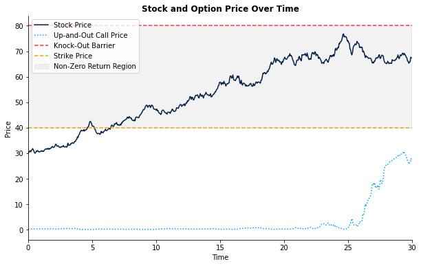

```python
S_0 = 30
sigma = 0.05
alpha = 0.02
dt = 0.05
T = 30
K = 40
B = 80
r = 0.05

#We generate stock prices, times and a list for the up-and-out call prices before populating it
stock_price_list = simulate_gbm(S_0, sigma, alpha, dt, T)
time_list = np.linspace(0, T, int(T/dt), endpoint = False)
up_and_out_call_price_list = np.zeros(int(T/dt))

knocked_out = 0

while knocked_out == 0:
    for i in range(len(stock_price_list)):
        if stock_price_list[i] >= B:
            knocked_out = 1

        up_and_out_call_price_list[i] = up_and_out_call_price(sigma, T, time_list[i], stock_price_list[i], K, B, r)*(1-knocked_out)
    break


plt.clf()

fig, ax = plt.subplots(figsize = (10, 6))

ax.plot(time_list, stock_price_list, color = (0, 0.13, 0.27), label = "Stock Price")
ax.plot(time_list, up_and_out_call_price_list, color = (0, 0.62, 0.99), ls = ":", label = "Up-and-Out Call Price")
ax.axhline(y = B, color = (0.98, 0.22, 0.26), label = "Knock-Out Barrier", ls = "--")
ax.axhline(y = K, color = (0.95, 0.65, 0.07), label = "Strike Price", ls = "--")
ax.fill_between(time_list, K, B, color = "gray", alpha = 0.1, label = "Non-Zero Return Region")

ax.set_xlim(left = 0, right = T)

ax.set_title("Stock and Option Price Over Time", fontweight = "semibold")
ax.set_xlabel("Time", fontweight = "medium")
ax.set_ylabel("Price", fontweight = "medium")

ax.legend(loc = "upper left")

ax.spines["top"].set_visible(False)
ax.spines["right"].set_visible(False)

plt.show()
```

Above, we can see that up-and-out call tends to have effectively zero value at first on account of the barrier $B$ being relatively close to the strike price $K$ and the discounting effect of $t$ being close to $0$. In fact, we note that as $B \downarrow K$, that $v(t, x) \downarrow 0$. Furthermore, as $B \rightarrow \infty$, we have that $v(t, x) \rightarrow c(t,x)$. This makes intuitive sense, as an incredibly high barrier relative to the current price of the underlying would be unlikely to ever be broken, thus rendering the up-and-out call effectively the same as a European call.

We have shaded the "Non-Zero Return Region" a light grey in the above. This represents the region between the strike price $K$ and the barrier $B$. We note that should the underlying asset's price end up in this region at time $T$, never having broken through the barrier $B$, then the payoff of the option shall be non-zero.

Finally, we note that the price of the up-and-out call is highly sensitive and can vary wildly as $t \rightarrow T$ if the underlying asset lies in the non-zero return region and has not broken the barrier.

We now consider plotting the price of the underlying stock price against both the vanilla European call and the up-and-out call.

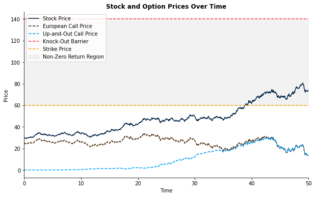

```python
S_0 = 30
sigma = 0.05
alpha = 0.02
dt = 0.05
T = 50
K = 60
B = 140
r = 0.05

#We generate stock prices, times and a list for both the European call and the up-and-out call prices before populating them
stock_price_list = simulate_gbm(S_0, sigma, alpha, dt, T)
time_list = np.linspace(0, T, int(T/dt), endpoint = False)
euro_call_price_list = np.zeros(int(T/dt))
up_and_out_call_price_list = np.zeros(int(T/dt))

for i in range(len(stock_price_list)):
    euro_call_price_list[i] = euro_call_price(sigma, T, time_list[i], stock_price_list[i], K, r)
    up_and_out_call_price_list[i] = up_and_out_call_price(sigma, T, time_list[i], stock_price_list[i], K, B, r)

plt.clf()

fig, ax = plt.subplots(figsize = (10, 6))

ax.plot(time_list, stock_price_list, color = (0, 0.13, 0.27), label = "Stock Price")
ax.plot(time_list, euro_call_price_list, color = (0.27, 0.13, 0), ls = "--", label = "European Call Price")
ax.plot(time_list, up_and_out_call_price_list, color = (0, 0.62, 0.99), ls = "--", label = "Up-and-Out Call Price")
ax.axhline(y = B, color = (0.98, 0.22, 0.26), label = "Knock-Out Barrier", ls = "--")
ax.axhline(y = K, color = (0.95, 0.65, 0.07), label = "Strike Price", ls = "--")
ax.fill_between(time_list, K, B, color = "gray", alpha = 0.1, label = "Non-Zero Return Region")

ax.set_xlim(left = 0, right = T)

ax.set_title("Stock and Option Prices Over Time", fontweight = "semibold")
ax.set_xlabel("Time", fontweight = "medium")
ax.set_ylabel("Price", fontweight = "medium")

ax.legend(loc = "upper left")

ax.spines["top"].set_visible(False)
ax.spines["right"].set_visible(False)

plt.show()
```

We note that as $t \rightarrow T$ and thus as $\tau \rightarrow 0$, that in certain iterations, depending upon the price of the underlying asset, $v\left(t, x\right) \rightarrow c\left(t, x\right)$.

If we rewrite the formulas for the two option prices, using the $\delta_{\pm}$ notation, we have that:

$$\begin{align*} c\left(t, x\right) &= xN\left(\delta_{+}\left(\tau, \frac{x}{K}\right)\right) - e^{-r\tau}KN\left(\delta_{-}\left(\tau, \frac{x}{K}\right)\right), \\ v\left(t, x\right) &= x\left[N\left(\delta_{+}\left(\tau, \frac{x}{K}\right)\right) - N\left(\delta_{+}\left(\tau, \frac{x}{B}\right)\right)\right] \\ &\quad - e^{-r\tau}K\left[N\left(\delta_{-}\left(\tau, \frac{x}{K}\right)\right) - N\left(\delta_{-}\left(\tau, \frac{x}{B}\right)\right)\right] \\ &\quad - B\left(\frac{x}{B}\right)^{-\frac{2r}{\sigma^2}}\left[N\left(\delta_{+}\left(\tau, \frac{B^2}{Kx}\right)\right) - N\left(\delta_{+}\left(\tau, \frac{B}{x}\right)\right)\right] \\ &\quad + e^{-r\tau}K\left(\frac{x}{B}\right)^{-\frac{2r}{\sigma^2}+1}\left[N\left(\delta_{-}\left(\tau, \frac{B^2}{Kx}\right)\right) - N\left(\delta_{-}\left(\tau, \frac{B}{x}\right)\right)\right], \\ &\quad \text{for } 0 \leq t < T, \, 0 \leq x \leq B. \end{align*}$$

As above, we have that

$$\begin{align*} \lim_{\tau\to0}\delta_{\pm}\left(\tau, s\right) &= \lim_{\tau\to0}\frac{1}{\sigma\sqrt{\tau}}\left[log\left(s\right) + \left(r \pm \frac{1}{2}\sigma^2\right)\tau\right]\\ &= \begin{cases} \infty, & \text{if } log\left(s\right) \gt 0,\\ -\infty, & \text{if } log\left(s\right) \lt 0,\\ 0, & \text{if } log\left(s\right) = 0. \end{cases} \end{align*}$$

Thus, fixing $x$ such that $x \in \left(K, B\right)$, we have that $\frac{x}{K} \gt 1$ and $\frac{x}{B} \lt 1$. It follows that, for such $x$, we have that $log\left(\frac{x}{K}\right) \gt 0$ and $log\left(\frac{x}{B}\right) \lt 0$.

Similarly to the above, this results in the following limits:

$$ \begin{align*} \lim_{\tau\to0} N\left(\delta_{\pm}\left(\tau, \frac{x}{K}\right)\right) &= 1,\\ \lim_{\tau\to0} N\left(\delta_{\pm}\left(\tau, \frac{x}{B}\right)\right) &= 0,\\ \lim_{\tau\to0} N\left(\delta_{\pm}\left(\tau, \frac{B^2}{Kx}\right)\right) &= 1,\\ \lim_{\tau\to0} N\left(\delta_{\pm}\left(\tau, \frac{B}{x}\right)\right) &= 1. \end{align*} $$

Therefore, as above, we have that $$ \begin{align*} \lim_{\tau\to0}v\left(t, x\right) &= x - K\\ &= \lim_{\tau\to0}c\left(t, x\right). \end{align*} $$

Thus, we can say that for a small $\epsilon \gt 0$, there exists some $\delta \gt 0$ such that for $t \in \left(T - \delta, T\right)$, we have that

$$ v\left(t, x\right) \approx c\left(t,x\right), $$

for some fixed $x \in \left(K, B\right)$.

Furthermore, given we are calculating the price of both the European call and the up-and-out call using the same price $x$ at any given time $t$, it holds intuitively that as $t \rightarrow T$, we have that $v\left(t, x\right) \rightarrow c\left(t,x\right)$, when $x \in \left(K, B\right)$. We can see this on certain iterations of the code in the graph above as it appears after a certain $t$, the two prices converge and follow the same path.

### 6.6 Conclusion

In this section, we considered the solution to the modified Black-Scholes PDE for an up-and-out barrier option. We then provided the solution and showed that it was indeed a solution to the PDE.

We then proceeded to consider pricing an up-and-out call, which is a variant of a Barrier option, before exploring the relationship between the price of an up-and-out call in comparison to the price of a vanilla European call under certain circumstances.

In the next section, we shall once again consider the Monte-Carlo approach to pricing options by extending the work we did in Section 4 to cover the pricing of the up-and-out call too.

## 7. Numerical Pricing Methods for Pricing Barrier Options

This section is based on ideas found in [2] and [7].

### 7.1 Introduction

In this section, we shall again consider the Monte-Carlo method for pricing the up-and out call. We will simulate $n$ different paths of GBM, considering the payoff for an up-and-out call in each one, give a strike price $K$ and a barrier of $B$. We will then average this payoff and discount it back by $e^{-rT}$ to get a price for the up-and-out call at time $t = 0$.

We note that, the payoff at time $T$ of the up-and-out call is given by the following:

$$ v(T, S(T)) = (S(T) - K)^{+}\cdot\mathbb{1}\left\{\max_{t\in[0,T]}S(t)\leq B\right\}. $$

### 7.2 Pricing Up-and-Out Calls With the Monte-Carlo Method

We begin by writing a function that can evaluate the payoff at time $T$ for an up-and-out call given $S(t)\text{ for all }t\in[0,T]$.

```python
def up_and_out_call_payoffs(paths, simulated_paths, K, B):
    payoffs = np.zeros(paths)

    idx = 0

    for path in simulated_paths:
        max_price = np.max(path) #Here we calculate the indicator function part of the payoff
        if max_price > B:
            payoffs[idx] = 0
        else:
            payoffs[idx] = max(path[-1] - K, 0)
        idx += 1

    return payoffs
```

We now define a function for the Monte-Carlo method of finding the price of an up-and-out call at time $t = 0$. We generate $n$ different stock price paths before using the function above to calculate the payoff of each of these paths at time $T$. We then average the payoffs and discount the value back to time $t = 0$ by multiplying the average by $e^{-rT}$.

```python
def mc_up_and_out_call_price(paths, S_0, sigma, alpha, dt, T, K, B, r):
    simulated_stock_paths = simulate_gbm_paths(paths, S_0, sigma, alpha, dt, T)
    up_and_out_call_payoffs_list = up_and_out_call_payoffs(paths, simulated_stock_paths, K, B)
    average_payoff = np.average(up_and_out_call_payoffs_list)
    return np.exp(-r*T)*average_payoff
```

We now test our function below.

```python
S_0 = 30
sigma = 0.05
alpha = 0.05
dt = 0.05
T = 50
paths = 500
r = alpha #We assume a risk-neutral position
K = 200
B = 300

up_and_out_call_mc_price = mc_up_and_out_call_price(paths, S_0, sigma, alpha, dt, T, K, B, r)

print("The price of the up-and-out call as per the Monte-Carlo method is {price:.2f}.".format(price = up_and_out_call_mc_price))
```

```
The price of the up-and-out call as per the Monte-Carlo method is 1.18.
```

## 8. Comparing Pricing Methodologies for Up-and-Out Barrier Calls

Similarly to Section 5, we now consider a comparison of the two methods for pricing an up-and-out call. Firstly, we show that the Monte-Carlo method does indeed provide an accurate estimate of the 'true' price as calculated using the closed-ended Black-Scholes equation. We then go on to consider the time-complexity of the two solutions, ultimately arriving at a similar conclusion to the one reached in Section 4.

We first price an up-and-out call using both the analytical Black-Scholes method and the numerical Monte-Carlo approximation, before examining the percentage difference between the two methods.

```python
S_0 = 100
sigma = 0.05
alpha = 0.05
dt = 0.05
t = 0
T = 10
paths = 2000
r = alpha #We assume a risk-neutral position
K = 200
B = 250

bs_price = up_and_out_call_price(sigma, T, t, S_0, K, B, r)
print("The price of the up-and-out call as per the Black-Scholes equation is {price:.2f}.".format(price = bs_price))

mc_price = mc_up_and_out_call_price(paths, S_0, sigma, alpha, dt, T, K, B, r)
print("The price of the up-and-out call as per the Monte-Carlo method is {price:.2f}.".format(price = mc_price))

difference = abs(mc_price - bs_price)
pct_difference = difference / bs_price

print("The absolute difference in price of the up-and-out call between the two methods is {diff:.2f}, which reflects ~{pct:.1%}".format(diff = difference, pct = pct_difference))
```

```
The price of the up-and-out call as per the Black-Scholes equation is 0.81.
The price of the up-and-out call as per the Monte-Carlo method is 0.78.
The absolute difference in price of the up-and-out call between the two methods is 0.02, which reflects ~3.0%
```

We now show that as $n$ increases, our function for pricing the up-and-out call using the Monte-Carlo method does indeed converge towards the price calculated using the closed-ended solution.

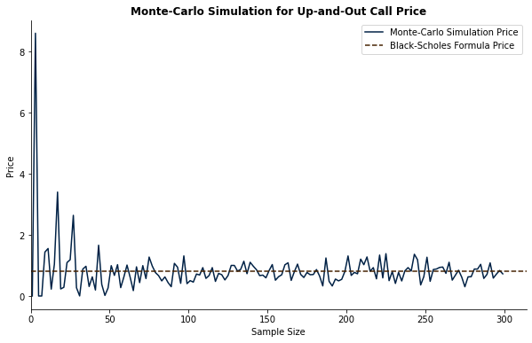

```python
sample_size_list = np.array(range(1,301,2))

mc_prices = np.zeros(len(sample_size_list))

for i in range(len(sample_size_list)):
    mc_prices[i] = mc_up_and_out_call_price(sample_size_list[i], S_0, sigma, alpha, dt, T, K, B, r)

bs_price = up_and_out_call_price(sigma, T, 0, S_0, K, B, r)

plt.clf()
fig, ax = plt.subplots(figsize=(10, 6))

ax.plot(sample_size_list, mc_prices, color = (0, 0.13, 0.27), label = "Monte-Carlo Simulation Price")
ax.axhline(y = bs_price, color = (0.27, 0.13, 0), label = "Black-Scholes Formula Price", ls = "--")

ax.set_xlim(left = 0)

ax.set_title("Monte-Carlo Simulation for Up-and-Out Call Price", fontweight = "semibold")
ax.set_xlabel("Sample Size", fontweight = "medium")
ax.set_ylabel("Price", fontweight = "medium")

ax.spines["top"].set_visible(False)
ax.spines["right"].set_visible(False)

ax.legend()

plt.show()
```

Once again, we see that as $n$ increases, the price generated by the Monte-Carlo method tends toward the closed-ended price calculated using the Black-Scholes equation.

We now consider the time-complexity of the two methods.

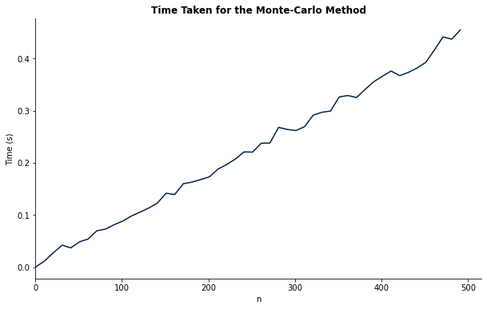

```python
sample_size_list = np.array(range(1, 501, 10))
time_taken_list = np.zeros(len(sample_size_list))

for i in range(len(sample_size_list)):
    start_time = time.time()
    mc_price = mc_up_and_out_call_price(sample_size_list[i], S_0, sigma, alpha, dt, T, K, B, r)
    end_time = time.time()

    time_taken = end_time - start_time
    time_taken_list[i] = time_taken


plt.clf()

fig, ax = plt.subplots(figsize=(10, 6))

ax.plot(sample_size_list, time_taken_list, color = (0, 0.13, 0.27))

ax.set_title("Time Taken for the Monte-Carlo Method", fontweight = "semibold")

ax.set_xlabel("n", fontweight = "medium")
ax.set_ylabel("Time (s)", fontweight = "medium")

ax.set_xlim(left = 0)

ax.spines["top"].set_visible(False)
ax.spines["right"].set_visible(False)

plt.show()
```

Once again, we have that the Monte-Carlo approximation function we have written has $O(n)$ time complexity. We now consider the Black-Scholes solution to pricing the option. We plot it against the time taken for the Monte-Carlo solution below.

[figure not shown]

```python
sample_size_list = np.array(range(1, 301, 20))
mc_time_taken_list = np.zeros(len(sample_size_list))
bs_time_taken_list = np.zeros(len(sample_size_list))

for i in range(len(sample_size_list)):
    mc_start_time = time.time()
    mc_price = mc_up_and_out_call_price(sample_size_list[i], S_0, sigma, alpha, dt, T, K, B, r)
    mc_end_time = time.time()

    mc_time_taken = mc_end_time - mc_start_time
    mc_time_taken_list[i] = mc_time_taken

    bs_start_time = time.time()
    bs_price = up_and_out_call_price(sigma, T, 0, S_0, K, B, r)
    bs_end_time = time.time()

    bs_time_taken = bs_end_time - bs_start_time
    bs_time_taken_list[i] = bs_time_taken


plt.clf()

fig, ax = plt.subplots(figsize=(10, 6))

ax.plot(sample_size_list, mc_time_taken_list, color = (0, 0.13, 0.27), label = "Monte-Carlo Method")
ax.plot(sample_size_list, bs_time_taken_list, color = (0.27, 0.13, 0), label = "Black-Scholes Equation")

ax.set_title("Time Taken for Up-and-Out Call Pricing Methods", fontweight = "semibold")

ax.set_xlabel("n", fontweight = "medium")
ax.set_ylabel("Time (s)", fontweight = "medium")

ax.set_xlim(left = 0)

ax.spines["top"].set_visible(False)
ax.spines["right"].set_visible(False)

ax.legend()

plt.show()
```

Once again, we see that the analytical solution has $O(1)$ time complexity.

Again, we see why the Monte-Carlo method is considered a method of last resort when pricing options and why a closed-ended, analytical solution is preferred if possible. Closed-ended solutions compute at a constant time in comparison to the Monte-Carlo simulations, which compute in linear time. In addition, the closed-ended solution is more accurate than the Monte-Carlo simulations. In order to achieve a higher degree of accuracy with the Monte-Carlo method, one would have to increase $n$, but as we can see from the figures above, increasing $n$ results in the time taken for the simulations to run increasing in a corresponding linear fashion, thus marking the lesser practicality of the Monte-Carlo method in comparison to the analytical, Black-Scholes pricing approach.

## 9. Conclusion

Throughout this project, we have considered both numerical and analytical methods for pricing options. We started by considering how we were going to model the price paths of the underlying security. Using GBM, we were able to progress to formulate an iterative method for coding a price path for the underlying security, assuming that it follows the GBM model.

Using this GBM model, and other assumptions for the BST, we considered the concept of constructing a portfolio $X(t)$ that hedges the price of the call at all times $t \in [0, T)$. We then discounted this portfolio and the price of a European call and used Itô's Lemma to derive a PDE involving the price of a European call, defined by $c(t, x)$, where $t$ is the time and $x = S(t)$ was the stock price at time $t$.

Using transformations, we were able to transform the Black-Scholes PDE into the Heat Equation, which has a known solution. This solution was then transformed back to give a solution to the Black-Scholes PDE, namely, a formula for the price of the option, $c(t, x)$, given the time of the stock $t$ and the price of the stock $x$ at that time $t$.

We then created a function in Python to enact this formula and showed how the price of a European call fluctuates in relation to the fluctuating price of the underlying asset. We then briefly considered theta decay - a value which reflects how quickly the value of the option decreases as time progresses.

Next we turned our attention to numerical methods, introducing the Monte-Carlo simulation, before using this method to also price European calls. We then briefly compared the two methods, drawing the conclusion that the analytical method is faster from a time complexity point of view and more accurate. This supported the general belief that a Monte-Carlo simulation approach to pricing options is only used in the event that an analytical solution either cannot be found or is deemed too complex to calculate.

Introducing exotic options, such as the path-dependent Barrier option, we repeated our analysis. Firstly, we considered the modified Black-Scholes PDE for this new type of option, before presenting a solution and verifying that it was indeed a solution to such an equation. We then used this solution to price up-and-out Barrier calls - one of several different types of Barrier options.

Once again, we considered Monte-Carlo methods too, again reaching the same conclusions, via similar comparisons, regarding the superiority of a closed-ended, analytical approach.

In conclusion, we have explored some of the methods available to price options. We have shown that, where possible, an analytical solution should be sought, on account of its time complexity superiority and accuracy, both of which are vital in environments that rely upon real-world applications of this mathematics. However, the Monte-Carlo method, alongside other numerical methods, should not be completely discarded. Not only can it serve as a sense-check with regards to the analytical method's accuracy, it also allows for the pricing of options in the event that an analytical solution does not exist or is too difficult to compute. In order to extend this project, we could consider a wider array of options to extend this methodological comparison to. We could also consider other methods of calculating the value of options, such as the Lattice Method, and contrast their use-cases, speed, and accuracy with both the analytical solutions available and the numerical Monte-Carlo method we have already explored.

## 10. References

[1] Black F and Scholes M (1973). The Pricing of Options and Corporate Liabilities. *Journal of Political Economy*, 81(3) pp. 637 - 654

[2] Boyle P (1977). Options: A Monte Carlo Approach. *Journal of Financial Economics*, 4(3) pp. 323 - 338

[3] Chan R (2021). *Black-Scholes Equations*, Financial Mathematics. Chinese University of Hong Kong. Available at: https://www.math.cuhk.edu.hk/~rchan/teaching/math4210/chap08.pdf

[4] Hull J (1989). *Options, Futures, and Other Derivatives* (9th edn). Boston: Pearson Education Limited

[5] Itô K (1951). On a Formula Concerning Stochastic Differential Equations. *Nagoya Mathematical Journal*, 3, pp. 55 - 65

[6] Law E (2019). *Finding the Solution to the Black-Scholes Equation*. Brookville: Long Island University. Available at: https://digitalcommons.liu.edu/cgi/viewcontent.cgi?article=1074&context=post_honors_theses

[7] Papatheodorou B (2005). *Enhanced Monte Carlo Methods for Pricing and Hedging Exotic Options*. Oxford: University of Oxford. Available at: https://people.maths.ox.ac.uk/gilesm/files/basileios.pdf

[8] Shreve S E (2010). *Stochastic Calculus for Finance II, Continuous-Time Models*, New York: Springer